# Cross-population heterogeneity analysis

A. Chong

2026-11-27

# 1 Analysis overview

The report analyses each matching exposure file in `../data/`. For every trait it includes the overall Cochran’s Q heterogeneity test, per-population Q contributions, multiple-testing correction, and EUR-referenced expected-versus-observed replication analyses. Overall and drug-target heterogeneity tests use separate Bonferroni thresholds based on the number of testable SNPs, with FDR-adjusted p-values reported alongside.

```r
knitr::kable(data.frame(trait = names(files), input = basename(files)),
            caption = "Exposure datasets selected for analysis")
```

Exposure datasets selected for analysis

| trait | input |
| --- | --- |
| dbp | dbp_pop_extract_common_snps_clumped_corrected.rds |
| hdl | hdl_pop_extract_common_snps_clumped_corrected.rds |
| ldlc | ldlc_pop_extract_common_snps_clumped_corrected.rds |
| pp | pp_pop_extract_common_snps_clumped_corrected.rds |
| sbp | sbp_pop_extract_common_snps_clumped_corrected.rds |
| tg | tg_pop_extract_common_snps_clumped_corrected.rds |

# 2 Analysis functions

```r
fixed_effects_meta_analysis <- function(beta_vec, se_vec) {
  if (length(beta_vec) != length(se_vec)) stop("beta_vec and se_vec must have equal lengths")
  keep <- is.finite(beta_vec) & is.finite(se_vec) & se_vec > 0
  beta_vec <- beta_vec[keep]
  se_vec <- se_vec[keep]
  n <- length(beta_vec)
  if (!n) return(list(beta = NA_real_, se = NA_real_, Q = NA_real_, Qdf = 0L,
                      Qpval = NA_real_, Qj = numeric(), Qjpval = numeric()))
  w <- 1 / se_vec^2
  beta <- sum(beta_vec * w) / sum(w)
  se <- sqrt(1 / sum(w))
  Qj <- w * (beta - beta_vec)^2
  Q <- sum(Qj)
  Qdf <- n - 1L
  Qpval <- if (Qdf > 0L) pchisq(Q, df = Qdf, lower.tail = FALSE) else NA_real_
  # Leave-one-out standardised residual: compare each population with the IVW
  # estimate of all *other* populations. Unlike Q_j, this is ~N(0, 1) under
  # homogeneity whatever the population's weight.
  loo_z <- if (n >= 2L) {
    vapply(seq_len(n), function(j) {
      b_minus <- sum(beta_vec[-j] * w[-j]) / sum(w[-j])
      se_minus <- sqrt(1 / sum(w[-j]))
      (beta_vec[j] - b_minus) / sqrt(se_vec[j]^2 + se_minus^2)
    }, numeric(1))
  } else rep(NA_real_, n)
  list(beta = beta, se = se, Q = Q, Qdf = Qdf, Qpval = Qpval,
       Qj = Qj, Qjpval = pchisq(Qj, df = 1, lower.tail = FALSE),
       loo_z = loo_z, loo_pval = 2 * pnorm(-abs(loo_z)))
}

combine_data <- function(sslist) {
  if (!length(sslist)) stop("sslist must not be empty")
  if (is.null(names(sslist)) || any(names(sslist) == "")) stop("sslist must be a named list")
  pieces <- lapply(seq_along(sslist), function(i) {
    pop <- names(sslist)[i]
    dat <- sslist[[i]]
    absent <- setdiff(c("snpid", "beta", "se"), names(dat))
    if (length(absent)) stop("Population ", pop, " is missing: ", paste(absent, collapse = ", "))
    dat <- dat %>% select(snpid, beta, se) %>% filter(!is.na(snpid)) %>%
      distinct(snpid, .keep_all = TRUE)
    names(dat)[names(dat) == "beta"] <- paste0("beta_", pop)
    names(dat)[names(dat) == "se"] <- paste0("se_", pop)
    dat
  })
  Reduce(function(x, y) full_join(x, y, by = "snpid"), pieces)
}

heterogeneity_test <- function(sslist, contribution = contribution_method) {
  contribution <- match.arg(contribution, c("loo", "qj"))
  contribution_field <- if (contribution == "loo") "loo_pval" else "Qjpval"
  if (length(sslist) < 2L) stop("At least two population datasets are required")
  if (is.null(names(sslist)) || any(names(sslist) == "")) stop("sslist must be a named list")
  joined <- combine_data(sslist)
  beta_cols <- paste0("beta_", names(sslist))
  se_cols <- paste0("se_", names(sslist))
  beta_mat <- as.matrix(joined[, beta_cols, drop = FALSE])
  se_mat <- as.matrix(joined[, se_cols, drop = FALSE])
  analyses <- lapply(seq_len(nrow(joined)), function(i) {
    fixed_effects_meta_analysis(as.numeric(beta_mat[i, ]), as.numeric(se_mat[i, ]))
  })
  q <- tibble::tibble(
    snpid = joined$snpid,
    beta_fixed = vapply(analyses, `[[`, numeric(1), "beta"),
    se_fixed = vapply(analyses, `[[`, numeric(1), "se"),
    Q = vapply(analyses, `[[`, numeric(1), "Q"),
    Qdf = vapply(analyses, `[[`, integer(1), "Qdf"),
    Qpval = vapply(analyses, `[[`, numeric(1), "Qpval"),
    n_pop = rowSums(is.finite(beta_mat) & is.finite(se_mat) & se_mat > 0)
  )
  qj_mat <- matrix(NA_real_, nrow = length(analyses), ncol = length(sslist),
                   dimnames = list(NULL, names(sslist)))
  for (i in seq_along(analyses)) {
    valid <- is.finite(beta_mat[i, ]) & is.finite(se_mat[i, ]) & se_mat[i, ] > 0
    if (any(valid)) qj_mat[i, valid] <- analyses[[i]][[contribution_field]]
  }
  qj <- as_tibble(qj_mat)
  qj$snpid <- joined$snpid
  list(Q = q, Qj = qj)
}

expected_vs_observed_replication <- function(b_disc, b_rep, se_disc, se_rep, alpha) {
  if (!(length(b_disc) == length(b_rep) && length(b_disc) == length(se_disc) &&
        length(b_disc) == length(se_rep))) stop("All vectors must have equal lengths")
  if (length(alpha) != 1L || !is.finite(alpha) || alpha <= 0 || alpha >= 1)
    stop("alpha must be between 0 and 1")
  keep <- is.finite(b_disc) & is.finite(b_rep) & is.finite(se_disc) &
    is.finite(se_rep) & se_disc > 0 & se_rep > 0
  b_disc <- b_disc[keep]; b_rep <- b_rep[keep]
  se_disc <- se_disc[keep]; se_rep <- se_rep[keep]
  p_sign <- pnorm(-abs(b_disc) / se_disc) * pnorm(-abs(b_disc) / se_rep) +
    (1 - pnorm(-abs(b_disc) / se_disc)) * (1 - pnorm(-abs(b_disc) / se_rep))
  # Expected power to reach two-sided significance in the replication sample if
  # the true effect equals the discovery estimate. (Previously the second term
  # used +abs(b_disc), so both terms were the lower tail and power was ~0.)
  p_sig <- pnorm(-abs(b_disc) / se_rep + qnorm(alpha / 2)) +
    (1 - pnorm(-abs(b_disc) / se_rep - qnorm(alpha / 2)))
  # Two-sided replication p-value, matching the two-sided expectation above.
  p_rep <- 2 * pnorm(abs(b_rep) / se_rep, lower.tail = FALSE)
  n <- length(b_disc)
  expected_sign <- sum(p_sign); observed_sign <- sum(sign(b_disc) == sign(b_rep))
  expected_sig <- sum(p_sig); observed_sig <- sum(p_rep < alpha)
  binom_p <- function(observed, expected) {
    if (n == 0L || expected <= 0 || expected >= n) NA_real_
    else binom.test(observed, n, expected / n)$p.value
  }
  list(
    res = tibble::tibble(nsnp = rep(n, 4), metric = c("Sign", "Sign", "P-value", "P-value"),
      datum = c("Expected", "Observed", "Expected", "Observed"),
      value = c(expected_sign, observed_sign, expected_sig, observed_sig),
      pdiff = c(NA_real_, binom_p(observed_sign, expected_sign), NA_real_,
                binom_p(observed_sig, expected_sig))),
    variants = tibble::tibble(expected_power = p_sig, observed_sig = p_rep < alpha,
      replication_fail = p_sig > 0.95 & !(p_rep < alpha),
      expected_sign = p_sign, observed_sign = sign(b_disc) == sign(b_rep),
      sign_fail = p_sign > 0.95 & !(sign(b_disc) == sign(b_rep)))
  )
}

forest_plot <- function(sslist, snp) {
  dat <- bind_rows(lapply(names(sslist), function(pop) {
    x <- sslist[[pop]]
    x <- x[x$snpid == snp, , drop = FALSE]
    if (!nrow(x)) return(NULL)
    tibble::tibble(beta = x$beta[1], se = x$se[1], label = pop)
  }))
  if (!nrow(dat)) stop("SNP not found: ", snp)
  ggplot(dat, aes(x = beta, y = label)) + geom_point() +
    geom_errorbarh(aes(xmin = beta - 1.96 * se, xmax = beta + 1.96 * se), height = 0) +
    geom_vline(xintercept = 0, linetype = "dotted") +
    labs(x = "Effect estimate (95% CI)", y = "Population") + theme_bw()
}
```

```r
plot_heterogeneous_snps <- function(dat, hits, plot_title) {
  if (!nrow(hits)) {
    cat("No SNPs pass the Bonferroni threshold for this analysis.\n")
    return(invisible(NULL))
  }
  plot_dat <- dat %>% semi_join(hits, by = "snpid") %>%
    mutate(pop = factor(pop, levels = populations))
  ggplot(plot_dat, aes(x = beta, y = pop, colour = pop)) +
    geom_errorbarh(aes(xmin = beta - 1.96 * se, xmax = beta + 1.96 * se), height = 0) +
    geom_point() + geom_vline(xintercept = 0, linetype = "dotted") +
    facet_wrap(vars(snpid), scales = "free_y") +
    labs(title = plot_title, x = "Effect estimate (95% CI)", y = "Population") +
    theme_bw() + theme(legend.position = "none", strip.text = element_text(size = 8))
}

# Forest plot for drug-target Bonferroni hits. Everything is derived from the
# data: SNPs are ordered by heterogeneity p-value (strongest at the top), strip
# labels are "chr:pos_<target gene>", the combined row is the IVW fixed-effect
# estimate from heterogeneity_test(), and the population making the largest
# contribution to Q (smallest per-population Q p-value) is drawn as a square.
# Returns a list of plots, with at most snps_per_page SNPs per plot.
plot_drug_hits_forest <- function(dat, hits, qj, plot_title, snps_per_page = 3,
                                  gene_cols = c("Target gene", "target_gene", "gene", "Gene")) {
  if (!nrow(hits)) {
    cat("No SNPs pass the Bonferroni threshold for this analysis.\n")
    return(invisible(NULL))
  }
  hits <- hits %>% arrange(Qpval)
  snp_order <- hits$snpid

  # Strip labels: chromosome:position followed by the annotated target gene.
  gene_col <- intersect(gene_cols, names(dat))[1]
  label_dat <- dat %>% filter(snpid %in% snp_order) %>% distinct(snpid, .keep_all = TRUE)
  genes <- if (is.na(gene_col)) rep(NA_character_, nrow(label_dat)) else as.character(label_dat[[gene_col]])
  strip_labels <- ifelse(is.na(genes) | genes == "", label_dat$snpid,
                         paste0(sub("_.*$", "", label_dat$snpid), "_", genes))
  strip_labels <- stats::setNames(strip_labels, label_dat$snpid)

  # Population with the largest Q contribution for each SNP.
  lead_pop <- qj %>% filter(snpid %in% snp_order) %>%
    pivot_longer(-snpid, names_to = "pop", values_to = "p") %>%
    filter(is.finite(p)) %>% group_by(snpid) %>% filter(p == min(p)) %>%
    ungroup() %>% transmute(snpid, pop, lead = TRUE)

  point_levels <- c("Population estimate", "Largest Q contribution", "Combined (IVW fixed effect)")
  plot_dat <- bind_rows(
    dat %>% filter(snpid %in% snp_order) %>% select(snpid, pop, beta, se) %>%
      mutate(pop = as.character(pop)),
    hits %>% transmute(snpid, pop = "Combined", beta = beta_fixed, se = se_fixed)
  ) %>%
    left_join(lead_pop, by = c("snpid", "pop")) %>%
    mutate(
      point_type = factor(case_when(pop == "Combined" ~ point_levels[3],
                                    !is.na(lead) ~ point_levels[2],
                                    TRUE ~ point_levels[1]), levels = point_levels),
      # Reverse so populations read top-down with Combined at the bottom.
      pop = factor(pop, levels = rev(c(populations, "Combined"))),
      snpid = factor(snpid, levels = snp_order)
    )

  # Split many hits across several figures so each panel stays legible.
  pages <- split(snp_order, ceiling(seq_along(snp_order) / snps_per_page))
  lapply(seq_along(pages), function(i) {
    page_title <- if (length(pages) > 1L)
      sprintf("%s (%d of %d)", plot_title, i, length(pages)) else plot_title
    page_dat <- plot_dat %>% filter(snpid %in% pages[[i]]) %>%
      mutate(snpid = factor(as.character(snpid), levels = pages[[i]]))
    forest_page(page_dat, strip_labels, point_levels, page_title)
  })
}

forest_page <- function(plot_dat, strip_labels, point_levels, plot_title) {
  ggplot(plot_dat, aes(x = beta, y = pop, shape = point_type)) +
    geom_point(size = 3) +
    geom_errorbarh(aes(xmin = beta - 1.96 * se, xmax = beta + 1.96 * se), height = 0) +
    geom_vline(xintercept = 0, linetype = "dotted") +
    facet_grid(snpid ~ ., switch = "y", scales = "free_y", space = "free_y",
               labeller = labeller(snpid = as_labeller(strip_labels))) +
    scale_shape_manual(values = stats::setNames(c(19, 15, 17), point_levels), drop = FALSE,
                       name = NULL) +
    labs(title = plot_title, x = "Beta (95% CI)") +
    theme(
      axis.title.y = element_blank(),
      axis.text.y = element_text(size = 11),
      axis.ticks.y = element_blank(),
      axis.text.x = element_text(size = 11),
      panel.background = element_blank(),
      panel.border = element_rect(colour = "black", fill = NA),
      strip.background = element_rect(colour = "black"),
      strip.text = element_text(colour = "black"),
      strip.placement = "outside",
      legend.position = "bottom"
    )
}

plot_qj <- function(qj, plot_title) {
  long <- qj %>% pivot_longer(-snpid, names_to = "population", values_to = "p") %>%
    filter(is.finite(p), p > 0, p <= 1)
  if (!nrow(long)) {
    cat("No per-population Q contribution p-values are available.\n")
    return(invisible(NULL))
  }
  ggplot(long, aes(x = snpid, y = -log10(p), colour = population)) +
    geom_point() + scale_colour_brewer(type = "qual") +
    labs(title = plot_title, x = "SNP", y = "-log10 per-population contribution p-value", colour = "Population") +
    theme_bw() + theme(panel.grid.minor = element_blank(), axis.text.x = element_blank(),
                       axis.ticks.x = element_blank())
}

# Genomic inflation factor from p-values: median(chi-square_1) / median under the null.
lambda_gc <- function(p) {
  chisq <- qchisq(pmax(pmin(p, 1), .Machine$double.xmin), df = 1, lower.tail = FALSE)
  median(chisq, na.rm = TRUE) / qchisq(0.5, df = 1)
}

# Standard error of lambda.
#   "bootstrap"  : resample SNPs with replacement (lambda_boot_n times) and take
#                  the SD of the bootstrap lambdas. Makes no distributional
#                  assumption; reproducible via lambda_boot_seed.
#   "asymptotic" : large-sample SE of a sample median, assuming the statistics
#                  follow lambda x chi-square_1:
#                  SE = lambda / (2 * f(m) * m * sqrt(n)), where m = median of
#                  chi-square_1 and f its density at m (SE ~= 2.33 lambda / sqrt(n)).
lambda_se <- function(p, method = lambda_se_method, B = lambda_boot_n) {
  p <- p[is.finite(p)]
  n <- length(p)
  if (n < 2L) return(NA_real_)
  if (method == "asymptotic") {
    m <- qchisq(0.5, df = 1)
    return(lambda_gc(p) / (2 * dchisq(m, df = 1) * m * sqrt(n)))
  }
  if (method != "bootstrap") stop("lambda_se_method must be 'bootstrap' or 'asymptotic'")
  boot <- vapply(seq_len(B), function(i) lambda_gc(sample(p, n, replace = TRUE)), numeric(1))
  stats::sd(boot)
}
```

```r
lambda_table <- function(qj) {
  long <- qj %>% pivot_longer(-snpid, names_to = "Population", values_to = "p") %>%
    filter(is.finite(p), p > 0, p <= 1)
  if (!nrow(long)) return(NULL)
  set.seed(lambda_boot_seed)
  long %>% group_by(Population) %>%
    summarise(n_snps = n(), lambda = lambda_gc(p), lambda_se = lambda_se(p),
              .groups = "drop") %>%
    # CI and test on the log scale (delta method: SE(log lambda) = SE / lambda),
    # which keeps the interval positive and suits a scale parameter.
    mutate(log_se = lambda_se / lambda,
           lambda_lci = lambda * exp(-1.96 * log_se),
           lambda_uci = lambda * exp(1.96 * log_se),
           # Two-sided Wald test of lambda = 1 on the log scale.
           p_lambda_eq_1 = 2 * pnorm(-abs(log(lambda) / log_se))) %>%
    select(-log_se)
}

make_qq_plot <- function(qj, plot_title) {
  qqdat <- qj %>% pivot_longer(-snpid, names_to = "Population", values_to = "p") %>%
    filter(is.finite(p), p > 0, p <= 1) %>%
    group_by(Population) %>% arrange(p, .by_group = TRUE) %>%
    mutate(observed = -log10(p), expected = -log10(ppoints(n())), rank = row_number(),
           n = n()) %>% ungroup()
  if (!nrow(qqdat)) {
    cat("No per-population Q contribution p-values are available for a QQ plot.\n")
    return(invisible(NULL))
  }
  lambda_df <- lambda_table(qj)
  pop_labels <- sprintf("%s: lambda = %.2f (95%% CI %.2f, %.2f)", lambda_df$Population,
                        lambda_df$lambda, lambda_df$lambda_lci, lambda_df$lambda_uci)
  qqdat <- qqdat %>%
    mutate(Population = factor(Population, levels = lambda_df$Population, labels = pop_labels))

  # Pointwise 95% band for the expected QQ line under the null, using the beta
  # distribution of uniform order statistics (largest population n).
  n_max <- max(qqdat$n)
  band <- tibble::tibble(rank = seq_len(n_max)) %>%
    mutate(expected = -log10(ppoints(n_max)),
           lo = -log10(qbeta(0.975, rank, n_max - rank + 1)),
           hi = -log10(qbeta(0.025, rank, n_max - rank + 1)))

  qq <- ggplot(qqdat, aes(expected, observed, colour = Population)) +
    geom_ribbon(data = band, aes(x = expected, ymin = lo, ymax = hi), inherit.aes = FALSE,
                fill = "grey85", alpha = 0.7) +
    geom_abline(intercept = 0, slope = 1, linetype = "dashed", colour = "black") +
    geom_point(size = 1.5, alpha = 0.7) +
    scale_color_brewer(palette = "Dark2", name = "Population") +
    labs(title = plot_title, x = "Expected -log10(P)", y = "Observed -log10(P)",
         caption = sprintf("Grey band: pointwise 95%% null interval. lambda SE by %s%s.",
                           lambda_se_method,
                           if (lambda_se_method == "bootstrap")
                             sprintf(" (%d resamples)", lambda_boot_n) else "")) +
    theme_bw() + theme(panel.grid = element_blank(), legend.position = "right")
  print(qq)

  # Lambda estimates with 95% CIs; the dashed line marks no inflation.
  forest <- ggplot(lambda_df, aes(x = lambda, y = factor(Population, levels = rev(Population)),
                                  colour = Population)) +
    geom_vline(xintercept = 1, linetype = "dashed") +
    geom_errorbarh(aes(xmin = lambda_lci, xmax = lambda_uci), height = 0.2) +
    geom_point(size = 2.5) +
    scale_color_brewer(palette = "Dark2", guide = "none") +
    labs(title = paste0(sub(" QQ plot$", "", plot_title), ": lambda with 95% CI"), x = "lambda (log scale)", y = NULL) +
    scale_x_log10() +
    theme_bw() + theme(panel.grid.minor = element_blank())
  print(forest)

  cat("\n\n")
  print(knitr::kable(lambda_df, digits = 3,
    caption = paste("Genomic inflation (lambda) by population with standard error, 95% CI and Wald test of lambda = 1",
                    "(CI and test on the log scale; estimates from fewer than ~50 SNPs are imprecise)")))
  cat("\n\n")
  invisible(list(qq = qq, forest = forest, lambda = lambda_df))
}

replication_by_population <- function(reference, target, selection_p, alpha) {
  if (!"pval" %in% names(reference)) return(NULL)
  disc <- reference %>% filter(is.finite(pval), pval < selection_p) %>%
    select(snpid, beta, se)
  paired <- disc %>% inner_join(target %>% select(snpid, beta, se), by = "snpid",
                                suffix = c("_disc", "_rep"))
  result <- expected_vs_observed_replication(
    paired$beta_disc, paired$beta_rep, paired$se_disc, paired$se_rep, alpha)
  list(res = result$res, variants = bind_cols(tibble::tibble(snpid = paired$snpid), result$variants),
       n_discovery = nrow(disc), n_paired = nrow(paired))
}

# Pair each non-EUR population with EUR and orient every SNP to the
# EUR effect-increasing allele (both betas flipped when the EUR beta is
# negative). Assumes alleles are already harmonised to EUR upstream.
eur_oriented_pairs <- function(dat, pops) {
  eur <- dat %>% filter(pop == "EUR") %>% select(snpid, beta_EUR = beta, se_EUR = se)
  dat %>% filter(pop %in% setdiff(pops, "EUR")) %>%
    select(snpid, pop, beta, se) %>%
    inner_join(eur, by = "snpid") %>%
    mutate(flip = ifelse(beta_EUR < 0, -1, 1),
           x = beta_EUR * flip, y = beta * flip,
           x_se = se_EUR, y_se = se)
}

# Per-population transferability summary against EUR:
#   IVW slope through the origin of non-EUR on EUR betas (weights 1/se_pop^2),
#   proportion of SNPs with the same sign, and the Pearson correlation.
transferability_summary <- function(pairs) {
  pairs %>% group_by(pop) %>%
    summarise(
      n_snps = n(),
      ivw_slope = sum(x * y / y_se^2) / sum(x^2 / y_se^2),
      ivw_slope_se = sqrt(1 / sum(x^2 / y_se^2)),
      sign_concordance = mean(y > 0),
      pearson_r = cor(x, y),
      .groups = "drop"
    ) %>%
    mutate(ivw_slope_lci = ivw_slope - 1.96 * ivw_slope_se,
           ivw_slope_uci = ivw_slope + 1.96 * ivw_slope_se,
           .after = ivw_slope_se)
}

# Grid of EUR vs non-EUR scatter plots: rows = traits, columns = populations.
# Every row shares its axis limits, so panels within a trait are comparable.
plot_cross_ancestry <- function(pairs_by_trait, plot_title = NULL, show_ci = TRUE) {
  label_of <- function(tr) dplyr::coalesce(unname(trait_labels[tr]), toupper(tr))
  pairs <- bind_rows(pairs_by_trait, .id = "trait") %>%
    mutate(trait_label = factor(label_of(trait), levels = label_of(names(pairs_by_trait))),
           pop = factor(pop, levels = intersect(setdiff(populations, "EUR"), unique(pop))))
  stats <- pairs %>% group_by(trait, trait_label) %>%
    group_modify(~ transferability_summary(.x)) %>%
    ungroup() %>%
    mutate(pop = factor(pop, levels = levels(pairs$pop))) %>%
    mutate(label = sprintf("slope %.2f (%.2f, %.2f)\nsign %.0f%%, n = %d",
                           ivw_slope, ivw_slope_lci, ivw_slope_uci,
                           100 * sign_concordance, n_snps))
  # Per-trait limits, shared across populations; include 0 and the x range
  # so the y = x line is always visible.
  lims <- pairs %>% group_by(trait_label) %>%
    summarise(xmax = max(x) * 1.05,
              ymin = min(c(y, 0)), ymax = max(c(y, x)), .groups = "drop")
  blank <- bind_rows(
    lims %>% transmute(trait_label, x = 0, y = ymin),
    lims %>% transmute(trait_label, x = xmax, y = ymax)
  ) %>% tidyr::crossing(pop = factor(levels(pairs$pop), levels = levels(pairs$pop)))
  ci <- pairs %>% left_join(lims, by = "trait_label") %>%
    mutate(lo = pmax(y - 1.96 * y_se, ymin), hi = pmin(y + 1.96 * y_se, ymax))
```

```r
  p <- ggplot(pairs, aes(x, y)) +
    geom_blank(data = blank) +
    geom_hline(yintercept = 0, colour = "grey85") +
    geom_abline(intercept = 0, slope = 1, linetype = "dashed", colour = "grey40")
  if (show_ci) {
    p <- p + geom_linerange(data = ci, aes(ymin = lo, ymax = hi),
                            colour = "grey70", alpha = 0.35, linewidth = 0.3)
  }
  p + geom_point(size = 0.9, alpha = 0.6) +
    geom_abline(data = stats, aes(intercept = 0, slope = ivw_slope),
                colour = "#1f77b4", linewidth = 0.6) +
    geom_text(data = stats, aes(x = -Inf, y = Inf, label = label),
              hjust = -0.05, vjust = 1.15, size = 2.6, lineheight = 0.9) +
    facet_wrap(vars(trait_label, pop), ncol = nlevels(pairs$pop), scales = "free") +
    scale_x_continuous(breaks = scales::breaks_pretty(n = 3)) +
    scale_y_continuous(breaks = scales::breaks_pretty(n = 4)) +
    labs(title = plot_title,
         x = "European beta (oriented to EUR effect-increasing allele)",
         y = "Non-European beta (same allele)") +
    theme_bw() +
    theme(panel.grid = element_blank(),
          strip.background = element_rect(fill = "grey95"),
          strip.text = element_text(face = "bold"))
}
```

# 3 Results by exposure

```r
all_pairs <- list()
all_transferability <- list()
for (trait in names(files)) {
  cat("\n## ", toupper(trait), "\n\n", sep = "")
  dat <- readRDS(files[[trait]])
  required <- c("snpid", "pop", "beta", "se")
  absent <- setdiff(required, names(dat))
  if (length(absent)) {
    cat("Skipped: required columns missing: ", paste(absent, collapse = ", "), "\n\n", sep = "")
    next
  }
  dat <- dat %>% filter(pop %in% populations, !is.na(snpid), is.finite(beta),
                        is.finite(se), se > 0) %>% arrange(pop, snpid) %>%
    distinct(pop, snpid, .keep_all = TRUE)
  pops <- populations[populations %in% unique(dat$pop)]
  if (length(pops) < 2L) {
    cat("Skipped: fewer than two configured populations have valid data.\n\n")
    next
  }
  sslist <- stats::setNames(lapply(pops, function(p) filter(dat, pop == p)), pops)
  result <- heterogeneity_test(sslist)

  # EUR-referenced transferability: IVW slope, sign concordance, correlation.
  if ("EUR" %in% pops) {
    all_pairs[[trait]] <- eur_oriented_pairs(dat, pops)
    all_transferability[[trait]] <- transferability_summary(all_pairs[[trait]]) %>%
      mutate(trait = trait, .before = 1)
  }
  n_tests <- sum(!is.na(result$Q$Qpval))
  mt_thres <- if (n_tests > 0L) alpha / n_tests else NA_real_
  result$Q <- result$Q %>% mutate(fdr = p.adjust(Qpval, method = "BH")) %>% arrange(Qpval)
  hits <- result$Q %>% filter(!is.na(Qpval), Qpval <= mt_thres)
  nominal_hits <- result$Q %>% filter(!is.na(Qpval), Qpval < alpha)

  counts <- tibble::tibble(population = pops,
    variants = vapply(pops, function(p) sum(dat$pop == p), integer(1)))
  summary <- tibble::tibble(
    variants_tested = n_tests,
    bonferroni_threshold = mt_thres,
    nominal_Q_p_lt_0_05 = nrow(nominal_hits),
    bonferroni_significant = nrow(hits),
    FDR_lt_0_05 = sum(result$Q$fdr < alpha, na.rm = TRUE),
    smallest_Q_p = if (!n_tests) NA_real_ else min(result$Q$Qpval, na.rm = TRUE),
    smallest_FDR = if (all(is.na(result$Q$fdr))) NA_real_ else min(result$Q$fdr, na.rm = TRUE)
  )
  cat("**Variant counts by population**\n\n")
  print(knitr::kable(counts))
  cat("\n\n**Overall heterogeneity summary**\n\n")
  print(knitr::kable(summary, digits = 5))
  if (!is.null(all_transferability[[trait]])) {
    cat("\n\n**Transferability versus EUR (SNPs oriented to the EUR effect-increasing allele)**\n\n")
    print(knitr::kable(all_transferability[[trait]] %>% select(-trait), digits = 3))
  }
  cat("\n\n**SNPs passing this trait's Bonferroni threshold**\n\n")
  print(knitr::kable(hits %>% select(snpid, n_pop, beta_fixed, se_fixed, Q, Qdf, Qpval, fdr), digits = 5))
  cat("\n\n**Nominally heterogeneous SNPs (Q p < 0.05): per-population Q contributions**\n\n")
  if (nrow(nominal_hits)) {
    nominal_qj <- result$Qj %>% semi_join(nominal_hits, by = "snpid")
    print(knitr::kable(nominal_qj, digits = 5))
  } else {
    cat("No SNPs have nominal Q p < 0.05.\n")
  }
  cat("\n\n**Per-population Q contribution plot** (method: ", contribution_method, ")\n\n", sep = "")
  print(plot_qj(result$Qj, paste0(toupper(trait), ": per-population Q contributions")))
  cat("\n\n**QQ plot and genomic inflation estimates for per-population Q contributions**\n\n")
  make_qq_plot(result$Qj, paste0(toupper(trait), ": per-population Q contribution QQ plot"))
  cat("\n\n**Population-specific estimates for Bonferroni-significant SNPs**\n\n")
  print(plot_heterogeneous_snps(dat, hits, paste0(toupper(trait), ": Bonferroni-significant heterogeneity SNPs")))

  qj_long <- result$Qj %>% pivot_longer(-snpid, names_to = "population", values_to = "p") %>%
    filter(!is.na(p))
  qj_summary <- qj_long %>% group_by(population) %>%
    summarise(variants_with_estimate = n(),
      fraction_contribution_p_lt_0_05 = mean(p < alpha), .groups = "drop") %>%
    arrange(desc(fraction_contribution_p_lt_0_05))
  cat("\n\n**Population-level Q contribution summary**\n\n")
  print(knitr::kable(qj_summary, digits = 3))

  # EUR-referenced expected-versus-observed replication for the full exposure.
  if ("EUR" %in% pops && "pval" %in% names(dat)) {
    cat("\n\n### Expected versus observed replication: all exposure SNPs\n\n")
    reference <- filter(dat, pop == "EUR")
    replication_rows <- list()
    replication_failures <- list()
    for (target_pop in setdiff(pops, "EUR")) {
      comparison <- replication_by_population(reference, filter(dat, pop == target_pop),
                                               replication_discovery_p, alpha)
      if (is.null(comparison)) next
      # Save the list values before mutate creates a column with the same name.
      n_discovery <- comparison$n_discovery
      n_paired <- comparison$n_paired
      replication_rows[[target_pop]] <- comparison$res %>%
        mutate(comparison = paste("EUR vs", target_pop),
               n_discovery = n_discovery, n_paired = n_paired, .before = 1)
      if (nrow(comparison$variants)) {
        replication_failures[[target_pop]] <- comparison$variants %>%
          mutate(comparison = paste("EUR vs", target_pop), .before = 1)
      }
    }
    if (length(replication_rows)) {
      replication_table <- bind_rows(replication_rows)
      print(knitr::kable(replication_table, digits = 5,
        caption = paste0("EUR discovery SNPs with p < ", format(replication_discovery_p, scientific = TRUE),
                         "; replication significance alpha = 0.05")))
      failure_table <- bind_rows(replication_failures)
      if (nrow(failure_table)) {
        failures <- failure_table %>% filter(replication_fail | sign_fail) %>%
          select(comparison, snpid, expected_power, observed_sig, replication_fail,
                 expected_sign, observed_sign, sign_fail)
        cat("\n\n**Variants with expected-but-not-observed replication**\n\n")
        if (nrow(failures)) print(knitr::kable(failures, digits = 5)) else cat("No variants meet the expected replication failure criteria.\n")
      }
    } else {
      cat("Replication analysis skipped: EUR estimates or p-values are unavailable.\n")
    }
  } else {
    cat("\n\nReplication analysis skipped: EUR data or p-values are unavailable.\n")
  }

  if ("Drug" %in% names(dat)) {
    dat_drug <- dat %>% filter(!is.na(Drug), as.character(Drug) != "")
    drug_pops <- pops[vapply(pops, function(p) any(dat_drug$pop == p), logical(1))]
    if (nrow(dat_drug) && length(drug_pops) >= 2L) {
      drug_sslist <- stats::setNames(lapply(drug_pops, function(p) filter(dat_drug, pop == p)), drug_pops)
      drug_result <- heterogeneity_test(drug_sslist)
      n_drug_tests <- sum(!is.na(drug_result$Q$Qpval))
      drug_mt_thres <- if (n_drug_tests > 0L) alpha / n_drug_tests else NA_real_
      drug_result$Q <- drug_result$Q %>% mutate(fdr = p.adjust(Qpval, method = "BH")) %>% arrange(Qpval)
      drug_hits <- drug_result$Q %>% filter(!is.na(Qpval), Qpval <= drug_mt_thres)
      drug_nominal_hits <- drug_result$Q %>% filter(!is.na(Qpval), Qpval < alpha)
      drug_map <- dat_drug %>% distinct(snpid, Drug)
      drug_summary <- drug_result$Q %>% left_join(drug_map, by = "snpid") %>%
        group_by(Drug) %>% summarise(n_snps = n_distinct(snpid),
          n_nominal_Q_p_lt_0_05 = n_distinct(snpid[snpid %in% drug_nominal_hits$snpid]),
          n_bonferroni_significant = n_distinct(snpid[snpid %in% drug_hits$snpid]),
          proportion_FDR_lt_0_05 = mean(fdr < alpha, na.rm = TRUE),
          median_Q_p = median(Qpval, na.rm = TRUE), median_FDR = median(fdr, na.rm = TRUE),
          min_FDR = min(fdr, na.rm = TRUE), .groups = "drop") %>%
        arrange(desc(n_bonferroni_significant), median_Q_p)
      cat("\n\n### Drug-target subset heterogeneity\n\n")
      cat("Tests: ", n_drug_tests, "; Bonferroni threshold: ", signif(drug_mt_thres, 5),
          "; significant SNPs: ", nrow(drug_hits), "\n\n", sep = "")
      cat("**Summary by drug class**\n\n")
      print(knitr::kable(drug_summary, digits = 4))
      cat("\n\n**Drug-target SNPs passing this subset's Bonferroni threshold**\n\n")
      print(knitr::kable(drug_hits %>% left_join(drug_map, by = "snpid") %>%
        select(snpid, Drug, n_pop, beta_fixed, se_fixed, Q, Qdf, Qpval, fdr), digits = 5))
      cat("\n\n**Nominal drug-target heterogeneity: per-population Q contributions**\n\n")
      if (nrow(drug_nominal_hits)) {
        drug_nominal_qj <- drug_result$Qj %>% semi_join(drug_nominal_hits, by = "snpid") %>%
          left_join(drug_map, by = "snpid")
        print(knitr::kable(drug_nominal_qj, digits = 5))
      } else {
        cat("No drug-target SNPs have nominal Q p < 0.05.\n")
      }
      cat("\n\n**Drug-target per-population Q contribution plot**\n\n")
      print(plot_qj(drug_result$Qj, paste0(toupper(trait), ": drug-target per-population Q contributions")))
      cat("\n\n**Drug-target QQ plot and genomic inflation estimates**\n\n")
      make_qq_plot(drug_result$Qj, paste0(toupper(trait), ": drug-target Q contribution QQ plot"))
      cat("\n\n**Population-specific estimates for drug-target Bonferroni hits**\n\n")
      drug_forest_plots <- plot_drug_hits_forest(dat_drug, drug_hits, drug_result$Qj,
        paste0(toupper(trait), ": drug-target Bonferroni-significant SNPs"))
      for (p in drug_forest_plots) print(p)

      drug_qj_summary <- drug_result$Qj %>% left_join(drug_map, by = "snpid") %>%
        pivot_longer(all_of(drug_pops), names_to = "population", values_to = "p") %>%
        group_by(Drug, population) %>%
        summarise(variants_with_estimate = sum(!is.na(p)),
          fraction_contribution_p_lt_0_05 = if (all(is.na(p))) NA_real_ else mean(p < alpha, na.rm = TRUE),
          .groups = "drop") %>% arrange(Drug, desc(fraction_contribution_p_lt_0_05))
      cat("\n\n**Per-population Q contribution fractions by drug class**\n\n")
      print(knitr::kable(drug_qj_summary, digits = 3))

      # Drug-target EUR replication, using nominal EUR discovery p < 0.05 as in
      # the original target-stratified analysis. Pair variants by identifier.
      if ("EUR" %in% drug_pops && "pval" %in% names(dat_drug)) {
        cat("\n\n### Expected versus observed replication: drug-target SNPs\n\n")
        drug_reference <- filter(dat_drug, pop == "EUR")
        drug_replication_rows <- list()
        for (target_pop in setdiff(drug_pops, "EUR")) {
          comparison <- replication_by_population(drug_reference, filter(dat_drug, pop == target_pop),
                                                   drug_replication_discovery_p, alpha)
          if (is.null(comparison)) next
          # Save the list values before mutate creates a column with the same name.
          n_discovery <- comparison$n_discovery
          n_paired <- comparison$n_paired
          drug_replication_rows[[target_pop]] <- comparison$res %>%
            mutate(comparison = paste("EUR vs", target_pop),
                   n_discovery = n_discovery, n_paired = n_paired, .before = 1)
        }
        if (length(drug_replication_rows)) {
          print(knitr::kable(bind_rows(drug_replication_rows), digits = 5,
            caption = paste0("Drug-target EUR discovery SNPs with p < ", drug_replication_discovery_p,
                             "; replication significance alpha = 0.05")))
        } else {
          cat("No drug-target replication comparisons are available.\n")
        }
      } else {
        cat("\n\nDrug-target replication skipped: EUR data or p-values are unavailable.\n")
      }
    } else {
      cat("\n\nDrug-target analysis skipped: fewer than two populations have annotated variants.\n")
    }
  } else {
    cat("\n\nNo `Drug` annotation column; drug-target analysis not applicable.\n")
  }
  cat("\n\n---\n\n")
}
```

## 3.1 DBP

**Variant counts by population**

| population | variants |
| --- | --- |
| AFR | 141 |
| AMR | 141 |
| EAS | 141 |
| EUR | 141 |
| SAS | 141 |
| UGR | 141 |

**Overall heterogeneity summary**

| variants_tested | bonferroni_threshold | nominal_Q_p_lt_0_05 | bonferroni_significant | FDR_lt_0_05 | smallest_Q_p | smallest_FDR |
| --- | --- | --- | --- | --- | --- | --- |
| 141 | 0.00035 | 28 | 5 | 10 | 0 | 0 |

**Transferability versus EUR (SNPs oriented to the EUR effect-increasing allele)**

| pop | n_snps | ivw_slope | ivw_slope_se | ivw_slope_lci | ivw_slope_uci | sign_concordance | pearson_r |
| --- | --- | --- | --- | --- | --- | --- | --- |
| AFR | 141 | 0.993 | 0.129 | 0.739 | 1.246 | 0.730 | 0.310 |
| AMR | 141 | 1.055 | 0.026 | 1.003 | 1.106 | 0.979 | 0.124 |
| EAS | 141 | 1.006 | 0.018 | 0.971 | 1.042 | 0.986 | 0.439 |
| SAS | 141 | 0.950 | 0.148 | 0.661 | 1.240 | 0.660 | 0.193 |
| UGR | 141 | 1.312 | 0.141 | 1.035 | 1.590 | 0.773 | 0.009 |

**SNPs passing this trait’s Bonferroni threshold**

| snpid | n_pop | beta_fixed | se_fixed | Q | Qdf | Qpval | fdr |
| --- | --- | --- | --- | --- | --- | --- | --- |
| 4:81182554_C_T | 6 | 0.64107 | 0.02642 | 71.91313 | 5 | 0.00000 | 0.00000 |
| 8:143992864_A_C | 6 | -0.22022 | 0.02499 | 37.71838 | 5 | 0.00000 | 0.00003 |
| 16:53803223_A_G | 6 | 0.21410 | 0.02828 | 37.06937 | 5 | 0.00000 | 0.00003 |
| 22:32079447_A_C | 6 | -0.25550 | 0.04646 | 35.24879 | 5 | 0.00000 | 0.00005 |
| 1:10796866_C_T | 6 | 0.27834 | 0.02559 | 23.01681 | 5 | 0.00034 | 0.00945 |

**Nominally heterogeneous SNPs (Q p < 0.05): per-population Q contributions**

| AFR | AMR | EAS | EUR | SAS | UGR | snpid |
| --- | --- | --- | --- | --- | --- | --- |
| 0.64875 | 0.97468 | 0.02615 | 0.07024 | 0.50342 | 0.00632 | 10:96015793_C_G |
| 0.77251 | 0.82683 | 0.25291 | 0.18793 | 0.10572 | 0.00317 | 11:16373664_C_T |
| 0.00215 | 0.29962 | 0.37650 | 0.79752 | 0.16119 | 0.95955 | 12:2519416_C_T |
| 0.14985 | 0.33427 | 0.07169 | 0.05279 | 0.03394 | 0.10337 | 12:50558974_A_G |
| 0.42134 | 0.00442 | 0.00387 | 0.00002 | 0.70010 | 0.62635 | 12:90025622_A_G |
| 0.69548 | 0.00180 | 0.93179 | 0.02338 | 0.48972 | 0.57654 | 15:75062397_C_T |
| 0.96577 | 0.77943 | 0.53919 | 0.50026 | 0.00931 | 0.02994 | 15:91437388_A_T |
| 0.47894 | 0.00000 | 0.04864 | 0.00000 | 0.35331 | 0.73766 | 16:53803223_A_G |
| 0.99144 | 0.00365 | 0.00028 | 0.36441 | 0.19665 | 0.05756 | 17:7133162_A_G |
| 0.13790 | 0.00646 | 0.11777 | 0.92144 | 0.14017 | 0.82933 | 19:17225128_A_G |
| 0.05857 | 0.75030 | 0.00003 | 0.00019 | 0.50827 | 0.58131 | 1:10796866_C_T |
| 0.87202 | 0.00525 | 0.20255 | 0.17807 | 0.02539 | 0.31650 | 1:236321459_C_T |
| 0.71914 | 0.01264 | 0.41357 | 0.00265 | 0.12280 | 0.10065 | 20:10742578_A_G |
| 0.68306 | 0.00000 | 0.29356 | 0.00001 | 0.28083 | 0.89367 | 22:32079447_A_C |
| 0.53676 | 0.00102 | 0.03908 | 0.00007 | 0.41459 | 0.94678 | 22:32397879_C_T |
| 0.40251 | 0.00351 | 0.85708 | 0.01297 | 0.60323 | 0.81863 | 2:240225455_A_G |
| 0.36053 | 0.00079 | 0.02586 | 0.00002 | 0.71076 | 0.92413 | 2:26911745_C_T |
| 0.02390 | 0.90562 | 0.00520 | 0.03045 | 0.94059 | 0.23960 | 3:169192040_C_T |
| 0.27141 | 0.00323 | 0.31489 | 0.00672 | 0.59328 | 0.13266 | 3:27562988_C_T |
| 0.13675 | 0.34158 | 0.01689 | 0.01849 | 0.12200 | 0.91136 | 3:53821207_C_T |
| 0.75492 | 0.00122 | 0.48717 | 0.00293 | 0.56646 | 0.70178 | 4:156433308_A_G |
| 0.98060 | 0.00224 | 0.00000 | 0.00000 | 0.43443 | 0.79777 | 4:81182554_C_T |
| 0.32921 | 0.41284 | 0.00020 | 0.00237 | 0.32404 | 0.65754 | 5:148361622_A_C |
| 0.28784 | 0.02425 | 0.00553 | 0.64910 | 0.89877 | 0.01483 | 7:150704843_A_G |
| 0.01292 | 0.00675 | 0.00063 | 0.35774 | 0.16186 | 0.98463 | 7:27245996_C_T |
| 0.65172 | 0.06236 | 0.00389 | 0.00049 | 0.32860 | 0.30619 | 8:120466959_C_T |
| 0.11983 | 0.09417 | 0.00000 | 0.00000 | 0.51278 | 0.14840 | 8:143992864_A_C |
| 0.47037 | 0.00044 | 0.80554 | 0.01585 | 0.80154 | 0.87610 | 8:76942271_C_T |

**Per-population Q contribution plot** (method: loo)

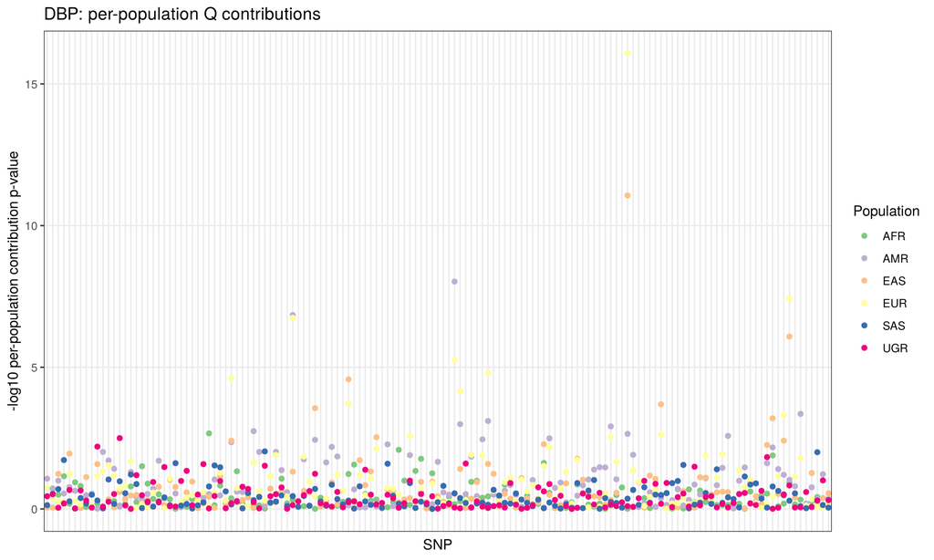

**QQ plot and genomic inflation estimates for per-population Q contributions**

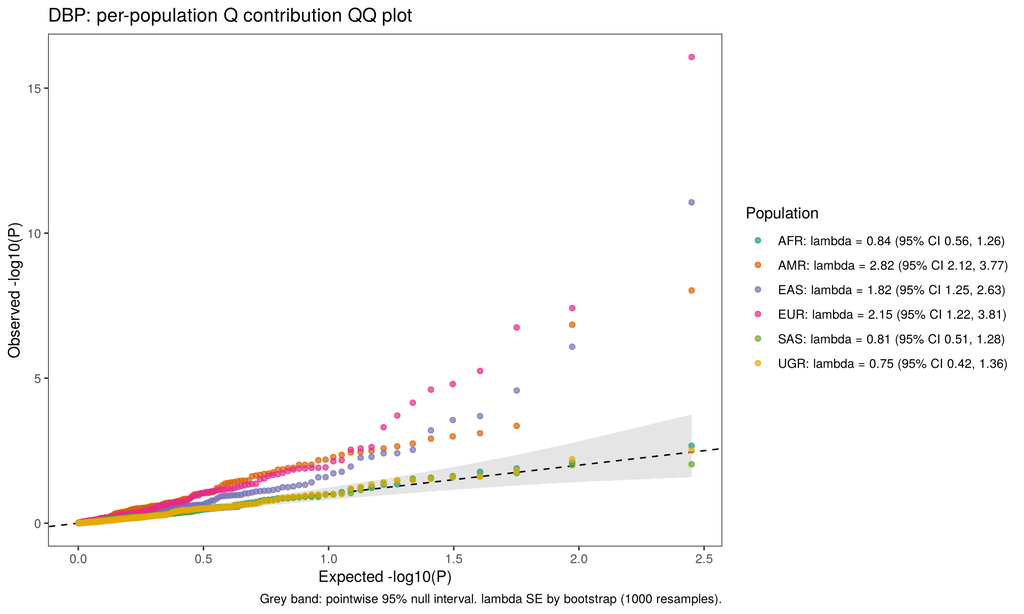

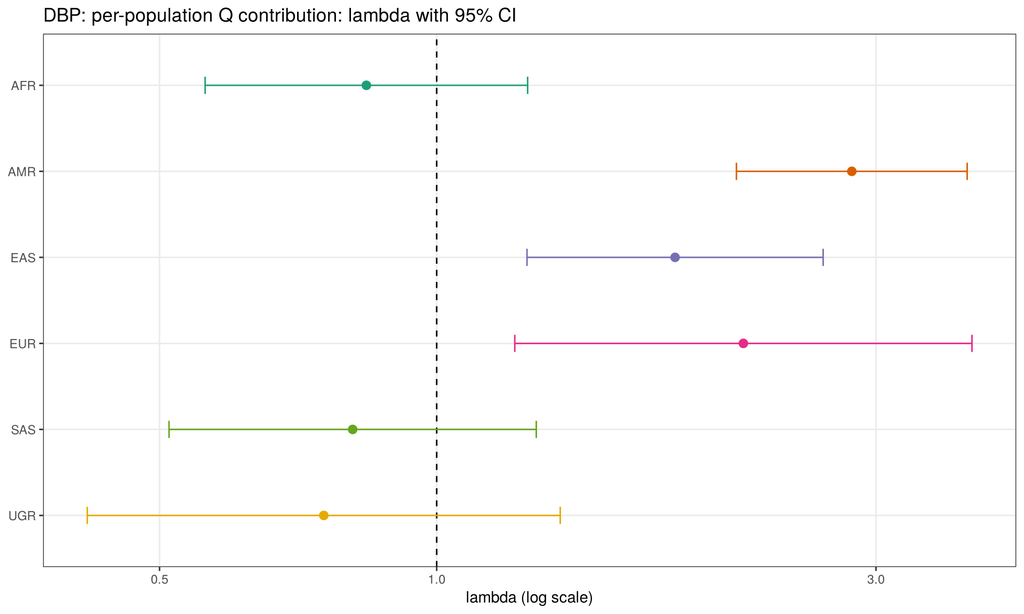

Genomic inflation (lambda) by population with standard error, 95% CI and Wald test of lambda = 1 (CI and test on the log scale; estimates from fewer than ~50 SNPs are imprecise)

| Population | n_snps | lambda | lambda_se | lambda_lci | lambda_uci | p_lambda_eq_1 |
| --- | --- | --- | --- | --- | --- | --- |
| AFR | 141 | 0.839 | 0.173 | 0.560 | 1.255 | 0.393 |
| AMR | 141 | 2.824 | 0.416 | 2.116 | 3.769 | 0.000 |
| EAS | 141 | 1.815 | 0.343 | 1.253 | 2.629 | 0.002 |
| EUR | 141 | 2.153 | 0.628 | 1.216 | 3.814 | 0.009 |
| SAS | 141 | 0.810 | 0.190 | 0.512 | 1.283 | 0.370 |
| UGR | 141 | 0.754 | 0.227 | 0.417 | 1.362 | 0.349 |

**Population-specific estimates for Bonferroni-significant SNPs**

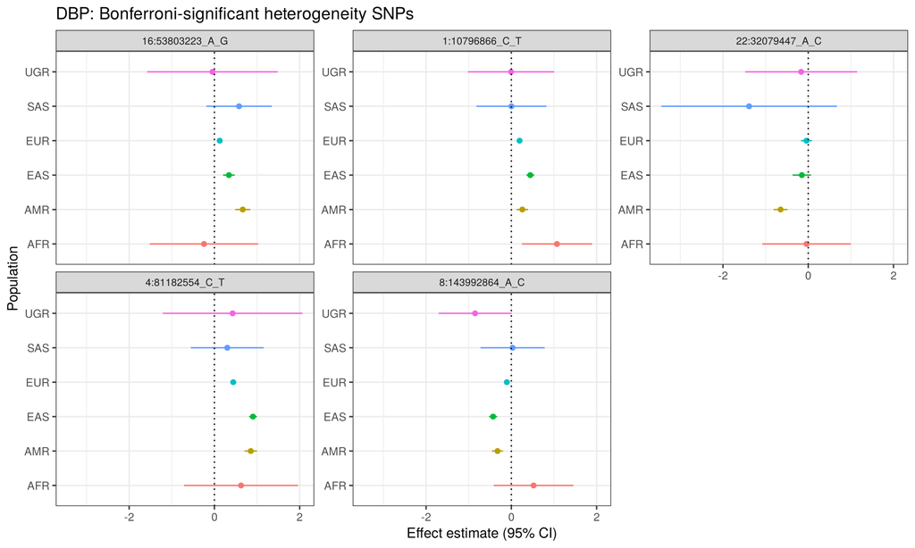

**Population-level Q contribution summary**

| population | variants_with_estimate | fraction_contribution_p_lt_0_05 |
| --- | --- | --- |
| AMR | 141 | 0.270 |
| EUR | 141 | 0.220 |
| EAS | 141 | 0.135 |
| UGR | 141 | 0.071 |
| AFR | 141 | 0.064 |
| SAS | 141 | 0.064 |

### 3.1.1 Expected versus observed replication: all exposure SNPs

EUR discovery SNPs with p < 5e-08; replication significance alpha = 0.05

| comparison | n_discovery | n_paired | nsnp | metric | datum | value | pdiff |
| --- | --- | --- | --- | --- | --- | --- | --- |
| EUR vs AFR | 89 | 89 | 89 | Sign | Expected | 66.75226 | NA |
| EUR vs AFR | 89 | 89 | 89 | Sign | Observed | 66.00000 | 0.90255 |
| EUR vs AFR | 89 | 89 | 89 | P-value | Expected | 10.21250 | NA |
| EUR vs AFR | 89 | 89 | 89 | P-value | Observed | 12.00000 | 0.50706 |
| EUR vs AMR | 89 | 89 | 89 | Sign | Expected | 88.67946 | NA |
| EUR vs AMR | 89 | 89 | 89 | Sign | Observed | 86.00000 | 0.00421 |
| EUR vs AMR | 89 | 89 | 89 | P-value | Expected | 76.89058 | NA |
| EUR vs AMR | 89 | 89 | 89 | P-value | Observed | 63.00000 | 0.00013 |
| EUR vs EAS | 89 | 89 | 89 | Sign | Expected | 88.50976 | NA |
| EUR vs EAS | 89 | 89 | 89 | Sign | Observed | 87.00000 | 0.08683 |
| EUR vs EAS | 89 | 89 | 89 | P-value | Expected | 82.10764 | NA |
| EUR vs EAS | 89 | 89 | 89 | P-value | Observed | 77.00000 | 0.06940 |
| EUR vs SAS | 89 | 89 | 89 | Sign | Expected | 65.08899 | NA |
| EUR vs SAS | 89 | 89 | 89 | Sign | Observed | 65.00000 | 1.00000 |
| EUR vs SAS | 89 | 89 | 89 | P-value | Expected | 8.85245 | NA |
| EUR vs SAS | 89 | 89 | 89 | P-value | Observed | 11.00000 | 0.47572 |
| EUR vs UGR | 89 | 89 | 89 | Sign | Expected | 65.16858 | NA |
| EUR vs UGR | 89 | 89 | 89 | Sign | Observed | 68.00000 | 0.55094 |
| EUR vs UGR | 89 | 89 | 89 | P-value | Expected | 9.21191 | NA |
| EUR vs UGR | 89 | 89 | 89 | P-value | Observed | 12.00000 | 0.29893 |

**Variants with expected-but-not-observed replication**

| comparison | snpid | expected_power | observed_sig | replication_fail | expected_sign | observed_sign | sign_fail |
| --- | --- | --- | --- | --- | --- | --- | --- |
| EUR vs AMR | 11:122527212_C_G | 0.97788 | FALSE | TRUE | 0.99996 | TRUE | FALSE |
| EUR vs AMR | 15:75062397_C_T | 0.99728 | FALSE | TRUE | 1.00000 | TRUE | FALSE |
| EUR vs AMR | 16:20392332_A_G | 0.97859 | FALSE | TRUE | 0.99997 | TRUE | FALSE |
| EUR vs AMR | 16:30979818_C_T | 0.97370 | FALSE | TRUE | 0.99995 | TRUE | FALSE |
| EUR vs AMR | 3:48185266_A_G | 0.96707 | FALSE | TRUE | 0.99993 | TRUE | FALSE |
| EUR vs AMR | 6:152316747_C_T | 0.44940 | FALSE | FALSE | 0.96657 | FALSE | TRUE |
| EUR vs AMR | 6:26019411_C_G | 0.95881 | FALSE | TRUE | 0.99989 | TRUE | FALSE |
| EUR vs AMR | 6:31878495_A_G | 0.47931 | FALSE | FALSE | 0.97180 | FALSE | TRUE |
| EUR vs AMR | 7:35477175_C_T | 0.59780 | FALSE | FALSE | 0.98636 | FALSE | TRUE |
| EUR vs AMR | 8:25906097_C_G | 0.97456 | FALSE | TRUE | 0.99995 | TRUE | FALSE |
| EUR vs EAS | 1:221358457_A_T | 0.99966 | FALSE | TRUE | 1.00000 | TRUE | FALSE |
| EUR vs EAS | 3:169192040_C_T | 0.99531 | FALSE | TRUE | 1.00000 | TRUE | FALSE |
| EUR vs EAS | 8:120466959_C_T | 0.81630 | FALSE | FALSE | 0.99789 | FALSE | TRUE |

### 3.1.2 Drug-target subset heterogeneity

Tests: 13; Bonferroni threshold: 0.0038462; significant SNPs: 0

**Summary by drug class**

| Drug | n_snps | n_nominal_Q_p_lt_0_05 | n_bonferroni_significant | proportion_FDR_lt_0_05 | median_Q_p | median_FDR | min_FDR |
| --- | --- | --- | --- | --- | --- | --- | --- |
| BB | 2 | 0 | 0 | 0 | 0.2074 | 0.4715 | 0.3022 |
| CCB | 10 | 2 | 0 | 0 | 0.3695 | 0.6145 | 0.2321 |
| ACEI | 1 | 0 | 0 | 0 | 0.4550 | 0.7394 | 0.7394 |

**Drug-target SNPs passing this subset’s Bonferroni threshold**

| snpid | Drug | n_pop | beta_fixed | se_fixed | Q | Qdf | Qpval | fdr |
| --- | --- | --- | --- | --- | --- | --- | --- | --- |

**Nominal drug-target heterogeneity: per-population Q contributions**

| AFR | AMR | EAS | EUR | SAS | UGR | snpid | Drug |
| --- | --- | --- | --- | --- | --- | --- | --- |
| 0.00215 | 0.29962 | 0.37650 | 0.79752 | 0.16119 | 0.95955 | 12:2519416_C_T | CCB |
| 0.13675 | 0.34158 | 0.01689 | 0.01849 | 0.12200 | 0.91136 | 3:53821207_C_T | CCB |

**Drug-target per-population Q contribution plot**

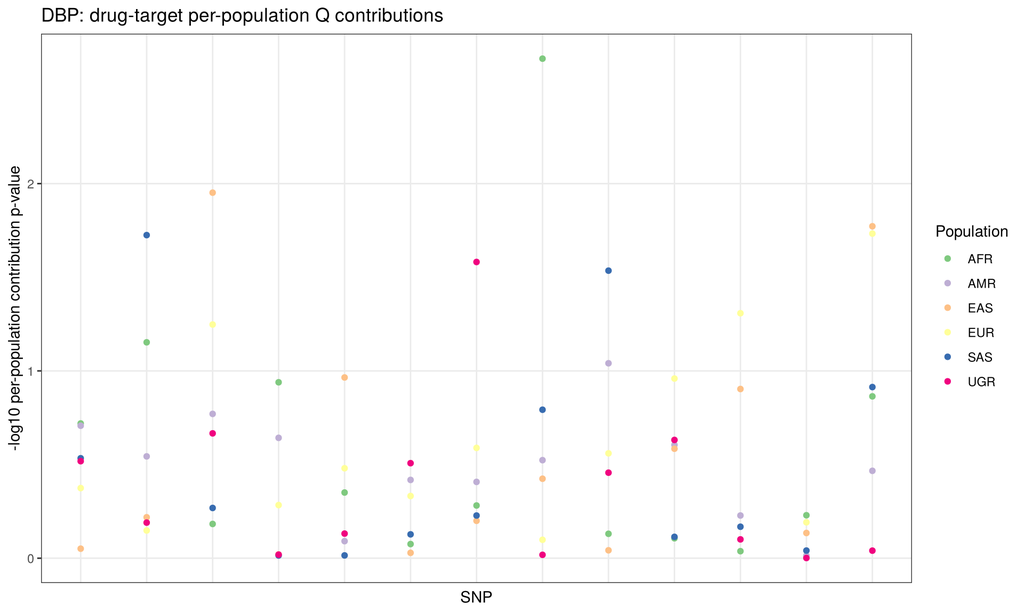

**Drug-target QQ plot and genomic inflation estimates**

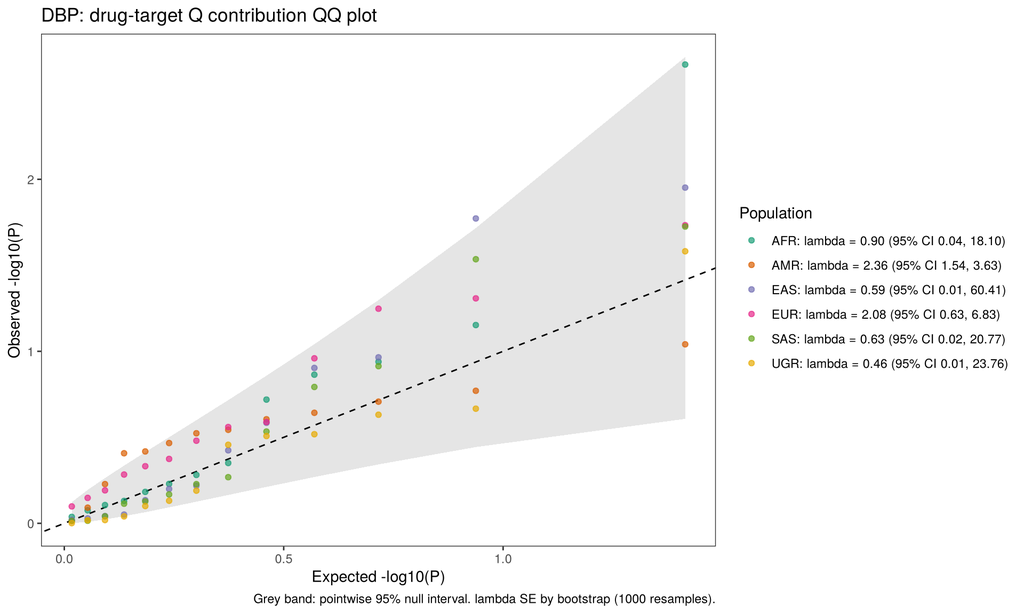

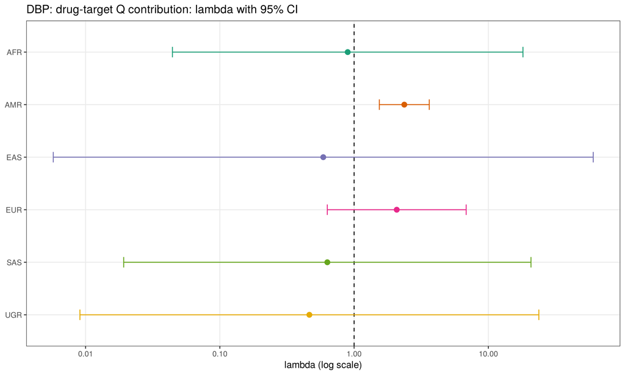

Genomic inflation (lambda) by population with standard error, 95% CI and Wald test of lambda = 1 (CI and test on the log scale; estimates from fewer than ~50 SNPs are imprecise)

| Population | n_snps | lambda | lambda_se | lambda_lci | lambda_uci | p_lambda_eq_1 |
| --- | --- | --- | --- | --- | --- | --- |
| AFR | 13 | 0.896 | 1.374 | 0.044 | 18.097 | 0.943 |
| AMR | 13 | 2.365 | 0.517 | 1.541 | 3.629 | 0.000 |
| EAS | 13 | 0.589 | 1.392 | 0.006 | 60.415 | 0.823 |
| EUR | 13 | 2.077 | 1.262 | 0.631 | 6.834 | 0.229 |
| SAS | 13 | 0.632 | 1.126 | 0.019 | 20.766 | 0.797 |
| UGR | 13 | 0.464 | 0.932 | 0.009 | 23.762 | 0.702 |

**Population-specific estimates for drug-target Bonferroni hits**

No SNPs pass the Bonferroni threshold for this analysis.

**Per-population Q contribution fractions by drug class**

| Drug | population | variants_with_estimate | fraction_contribution_p_lt_0_05 |
| --- | --- | --- | --- |
| ACEI | AFR | 1 | 0.0 |
| ACEI | AMR | 1 | 0.0 |
| ACEI | EAS | 1 | 0.0 |
| ACEI | EUR | 1 | 0.0 |
| ACEI | SAS | 1 | 0.0 |
| ACEI | UGR | 1 | 0.0 |
| BB | SAS | 2 | 0.5 |
| BB | AFR | 2 | 0.0 |
| BB | AMR | 2 | 0.0 |
| BB | EAS | 2 | 0.0 |
| BB | EUR | 2 | 0.0 |
| BB | UGR | 2 | 0.0 |
| CCB | EAS | 10 | 0.2 |
| CCB | EUR | 10 | 0.2 |
| CCB | AFR | 10 | 0.1 |
| CCB | SAS | 10 | 0.1 |
| CCB | UGR | 10 | 0.1 |
| CCB | AMR | 10 | 0.0 |

### 3.1.3 Expected versus observed replication: drug-target SNPs

Drug-target EUR discovery SNPs with p < 0.05; replication significance alpha = 0.05

| comparison | n_discovery | n_paired | nsnp | metric | datum | value | pdiff |
| --- | --- | --- | --- | --- | --- | --- | --- |
| EUR vs AFR | 12 | 12 | 12 | Sign | Expected | 8.38515 | NA |
| EUR vs AFR | 12 | 12 | 12 | Sign | Observed | 8.00000 | 0.76115 |
| EUR vs AFR | 12 | 12 | 12 | P-value | Expected | 1.08832 | NA |
| EUR vs AFR | 12 | 12 | 12 | P-value | Observed | 1.00000 | 1.00000 |
| EUR vs AMR | 12 | 12 | 12 | Sign | Expected | 11.65478 | NA |
| EUR vs AMR | 12 | 12 | 12 | Sign | Observed | 12.00000 | 1.00000 |
| EUR vs AMR | 12 | 12 | 12 | P-value | Expected | 7.84710 | NA |
| EUR vs AMR | 12 | 12 | 12 | P-value | Observed | 10.00000 | 0.23804 |
| EUR vs EAS | 12 | 12 | 12 | Sign | Expected | 11.69714 | NA |
| EUR vs EAS | 12 | 12 | 12 | Sign | Observed | 11.00000 | 0.26417 |
| EUR vs EAS | 12 | 12 | 12 | P-value | Expected | 8.44046 | NA |
| EUR vs EAS | 12 | 12 | 12 | P-value | Observed | 9.00000 | 1.00000 |
| EUR vs SAS | 12 | 12 | 12 | Sign | Expected | 7.91844 | NA |
| EUR vs SAS | 12 | 12 | 12 | Sign | Observed | 5.00000 | 0.12247 |
| EUR vs SAS | 12 | 12 | 12 | P-value | Expected | 0.88154 | NA |
| EUR vs SAS | 12 | 12 | 12 | P-value | Observed | 1.00000 | 0.59972 |
| EUR vs UGR | 12 | 12 | 12 | Sign | Expected | 8.17000 | NA |
| EUR vs UGR | 12 | 12 | 12 | Sign | Observed | 11.00000 | 0.11901 |
| EUR vs UGR | 12 | 12 | 12 | P-value | Expected | 0.98816 | NA |
| EUR vs UGR | 12 | 12 | 12 | P-value | Observed | 1.00000 | 1.00000 |

## 3.2 HDL

**Variant counts by population**

| population | variants |
| --- | --- |
| AFR | 141 |
| AMR | 141 |
| EAS | 141 |
| EUR | 141 |
| SAS | 141 |
| UGR | 141 |

**Overall heterogeneity summary**

| variants_tested | bonferroni_threshold | nominal_Q_p_lt_0_05 | bonferroni_significant | FDR_lt_0_05 | smallest_Q_p | smallest_FDR |
| --- | --- | --- | --- | --- | --- | --- |
| 141 | 0.00035 | 46 | 21 | 31 | 0 | 0 |

**Transferability versus EUR (SNPs oriented to the EUR effect-increasing allele)**

| pop | n_snps | ivw_slope | ivw_slope_se | ivw_slope_lci | ivw_slope_uci | sign_concordance | pearson_r |
| --- | --- | --- | --- | --- | --- | --- | --- |
| AFR | 141 | 0.778 | 0.095 | 0.593 | 0.964 | 0.723 | 0.210 |
| AMR | 141 | 1.037 | 0.018 | 1.001 | 1.072 | 0.957 | 0.607 |
| EAS | 141 | 1.101 | 0.043 | 1.017 | 1.186 | 0.794 | 0.622 |
| SAS | 141 | 0.993 | 0.087 | 0.823 | 1.162 | 0.709 | 0.473 |
| UGR | 141 | 0.934 | 0.163 | 0.614 | 1.254 | 0.660 | 0.063 |

**SNPs passing this trait’s Bonferroni threshold**

| snpid | n_pop | beta_fixed | se_fixed | Q | Qdf | Qpval | fdr |
| --- | --- | --- | --- | --- | --- | --- | --- |
| 16:56985139_A_G | 6 | -0.05455 | 0.00070 | 168.66568 | 5 | 0.00000 | 0.00000 |
| 11:117215605_C_T | 6 | -0.02198 | 0.00181 | 161.76245 | 5 | 0.00000 | 0.00000 |
| 11:116633825_C_T | 6 | -0.01265 | 0.00069 | 116.46313 | 5 | 0.00000 | 0.00000 |
| 16:56914355_C_T | 6 | -0.01502 | 0.00159 | 69.07731 | 5 | 0.00000 | 0.00000 |
| 1:63103217_A_G | 6 | 0.00727 | 0.00071 | 63.14973 | 5 | 0.00000 | 0.00000 |
| 19:45411941_C_T | 6 | -0.02777 | 0.00096 | 56.88839 | 5 | 0.00000 | 0.00000 |
| 15:60957248_A_G | 6 | -0.00300 | 0.00083 | 51.02655 | 5 | 0.00000 | 0.00000 |
| 16:56685601_A_G | 6 | 0.02438 | 0.00229 | 44.49325 | 5 | 0.00000 | 0.00000 |
| 9:107661742_A_C | 6 | 0.02510 | 0.00077 | 36.16468 | 5 | 0.00000 | 0.00001 |
| 6:160936588_A_G | 6 | -0.00448 | 0.00073 | 35.77477 | 5 | 0.00000 | 0.00001 |
| 15:58415030_C_G | 6 | -0.00811 | 0.00147 | 33.49902 | 5 | 0.00000 | 0.00004 |
| 20:44551855_C_T | 6 | -0.02223 | 0.00088 | 32.44302 | 5 | 0.00000 | 0.00006 |
| 12:121420263_A_G | 6 | 0.00705 | 0.00071 | 32.07798 | 5 | 0.00001 | 0.00006 |
| 8:9166532_C_T | 6 | -0.00794 | 0.00072 | 31.33147 | 5 | 0.00001 | 0.00008 |
| 19:54794205_C_T | 6 | 0.01654 | 0.00081 | 29.51665 | 5 | 0.00002 | 0.00017 |
| 15:58723426_A_G | 6 | -0.04564 | 0.00081 | 29.20462 | 5 | 0.00002 | 0.00019 |
| 12:7693399_C_T | 6 | -0.00757 | 0.00103 | 28.35403 | 5 | 0.00003 | 0.00026 |
| 11:116771589_A_T | 6 | -0.01357 | 0.00239 | 27.26167 | 5 | 0.00005 | 0.00040 |
| 12:125338529_C_T | 6 | -0.01391 | 0.00075 | 26.25245 | 5 | 0.00008 | 0.00059 |
| 15:57473203_A_G | 6 | 0.00391 | 0.00070 | 24.72642 | 5 | 0.00016 | 0.00111 |
| 9:107589744_C_T | 6 | -0.02628 | 0.00090 | 24.22579 | 5 | 0.00020 | 0.00132 |

**Nominally heterogeneous SNPs (Q p < 0.05): per-population Q contributions**

| AFR | AMR | EAS | EUR | SAS | UGR | snpid |
| --- | --- | --- | --- | --- | --- | --- |
| 0.06916 | 0.06637 | 0.61747 | 0.04820 | 0.91137 | 0.01031 | 10:64934548_C_T |
| 0.12452 | 0.00000 | 0.00000 | 0.00000 | 0.01708 | 0.50384 | 11:116633825_C_T |
| 0.02867 | 0.00001 | 0.12409 | 0.00001 | 0.96183 | 0.38551 | 11:116771589_A_T |
| 0.72765 | 0.00000 | 0.34240 | 0.00000 | 0.09787 | 0.29786 | 11:117215605_C_T |
| 0.70641 | 0.00126 | 0.76316 | 0.00348 | 0.64629 | 0.42311 | 11:66050712_A_G |
| 0.12937 | 0.00012 | 0.56638 | 0.00045 | 0.61123 | 0.68728 | 12:103522952_C_T |
| 0.83310 | 0.00000 | 0.49998 | 0.00000 | 0.40385 | 0.62305 | 12:121420263_A_G |
| 0.00041 | 0.03746 | 0.24501 | 0.00072 | 0.40544 | 0.01207 | 12:125338529_C_T |
| 0.55362 | 0.01955 | 0.00001 | 0.00002 | 0.87500 | 0.75231 | 12:7693399_C_T |
| 0.73074 | 0.00053 | 0.17251 | 0.00025 | 0.90620 | 0.24678 | 15:53008678_C_T |
| 0.98559 | 0.00000 | 0.79096 | 0.00001 | 0.90684 | 0.85349 | 15:57473203_A_G |
| 0.31794 | 0.00000 | 0.60646 | 0.00000 | 0.75058 | 0.08285 | 15:58415030_C_G |
| 0.75965 | 0.49656 | 0.02680 | 0.07582 | 0.08709 | 0.00001 | 15:58723426_A_G |
| 0.33934 | 0.00000 | 0.64258 | 0.00000 | 0.29311 | 0.06041 | 15:60957248_A_G |
| 0.00555 | 0.00000 | 0.00008 | 0.09570 | 0.47192 | 0.01692 | 16:56685601_A_G |
| 0.04545 | 0.00000 | 0.00000 | 0.00002 | 0.62955 | 0.42821 | 16:56914355_C_T |
| 0.00000 | 0.01482 | 0.00088 | 0.10204 | 0.67219 | 0.00000 | 16:56985139_A_G |
| 0.22332 | 0.88485 | 0.01378 | 0.05439 | 0.13062 | 0.00191 | 16:67985706_C_T |
| 0.67230 | 0.00007 | 0.11180 | 0.00001 | 0.67111 | 0.88041 | 17:41837264_C_G |
| 0.49396 | 0.00056 | 0.84796 | 0.00099 | 0.83087 | 0.47318 | 17:6929552_C_T |
| 0.07706 | 0.01056 | 0.10326 | 0.05572 | 0.76253 | 0.15978 | 18:47144663_C_T |
| 0.05330 | 0.00000 | 0.00509 | 0.00024 | 0.05487 | 0.37264 | 19:45411941_C_T |
| 0.55010 | 0.02792 | 0.42378 | 0.04162 | 0.01955 | 0.45314 | 19:45447161_C_T |
| 0.90958 | 0.89491 | 0.00008 | 0.07147 | 0.26716 | 0.00039 | 19:54794205_C_T |
| 0.46770 | 0.00085 | 0.02356 | 0.00003 | 0.06017 | 0.68604 | 1:230297136_C_T |
| 0.48143 | 0.00006 | 0.05990 | 0.00536 | 0.88204 | 0.40370 | 1:40043772_A_G |
| 0.05409 | 0.00000 | 0.00314 | 0.00000 | 0.43988 | 0.85216 | 1:63103217_A_G |
| 0.12261 | 0.00000 | 0.15368 | 0.00002 | 0.42798 | 0.93551 | 20:44551855_C_T |
| 0.01929 | 0.90640 | 0.96678 | 0.52553 | 0.44183 | 0.01519 | 21:46271452_C_T |
| 0.17495 | 0.02739 | 0.02272 | 0.00648 | 0.23071 | 0.90996 | 2:165528876_C_T |
| 0.59460 | 0.00008 | 0.16498 | 0.00002 | 0.98492 | 0.25338 | 2:211540507_A_C |
| 0.55559 | 0.01078 | 0.08780 | 0.00058 | 0.09905 | 0.67885 | 3:36960660_A_C |
| 0.20794 | 0.00496 | 0.87364 | 0.06200 | 0.11625 | 0.27902 | 4:89721332_C_T |
| 0.29710 | 0.08747 | 0.01483 | 0.01428 | 0.16927 | 0.00180 | 5:74649498_C_T |
| 0.17180 | 0.00001 | 0.00125 | 0.00000 | 0.46824 | 0.40924 | 6:160936588_A_G |
| 0.69495 | 0.01034 | 0.08537 | 0.17647 | 0.10202 | 0.33817 | 6:161017993_A_G |
| 0.77842 | 0.61271 | 0.00096 | 0.05369 | 0.55861 | 0.72696 | 6:43757896_A_C |
| 0.78385 | 0.05425 | 0.01383 | 0.74338 | 0.04274 | 0.38841 | 7:17919258_G_T |
| 0.92442 | 0.00088 | 0.58304 | 0.00834 | 0.85551 | 0.60516 | 7:73039406_C_G |
| 0.12063 | 0.00023 | 0.34748 | 0.00182 | 0.84051 | 0.57450 | 7:79833590_A_G |
| 0.58992 | 0.00235 | 0.54908 | 0.00189 | 0.28706 | 0.71385 | 8:144296480_C_G |
| 0.14207 | 0.05550 | 0.12414 | 0.12152 | 0.17905 | 0.04193 | 8:19912370_A_G |
| 0.28354 | 0.00000 | 0.15712 | 0.00002 | 0.50395 | 0.23347 | 8:9166532_C_T |
| 0.23746 | 0.00097 | 0.25236 | 0.00016 | 0.27134 | 0.63558 | 8:9183358_A_G |
| 0.11381 | 0.00510 | 0.12738 | 0.00005 | 0.00342 | 0.27911 | 9:107589744_C_T |
| 0.37080 | 0.00000 | 0.01173 | 0.00008 | 0.30461 | 0.42460 | 9:107661742_A_C |

**Per-population Q contribution plot** (method: loo)

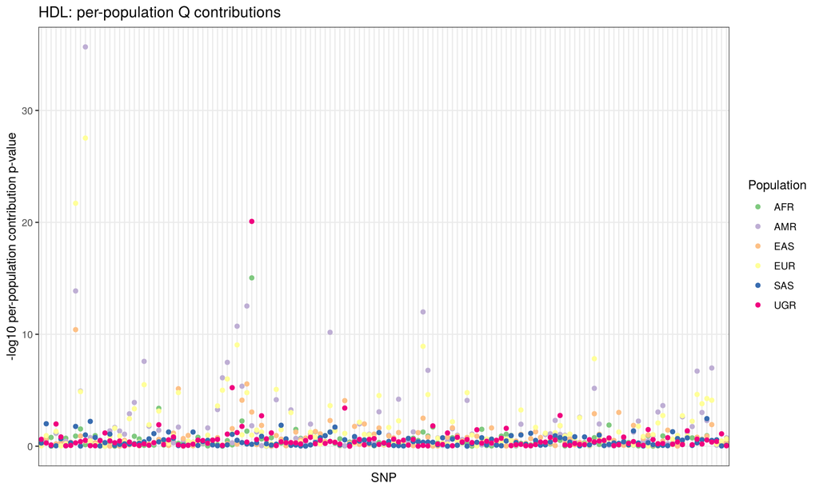

**QQ plot and genomic inflation estimates for per-population Q contributions**

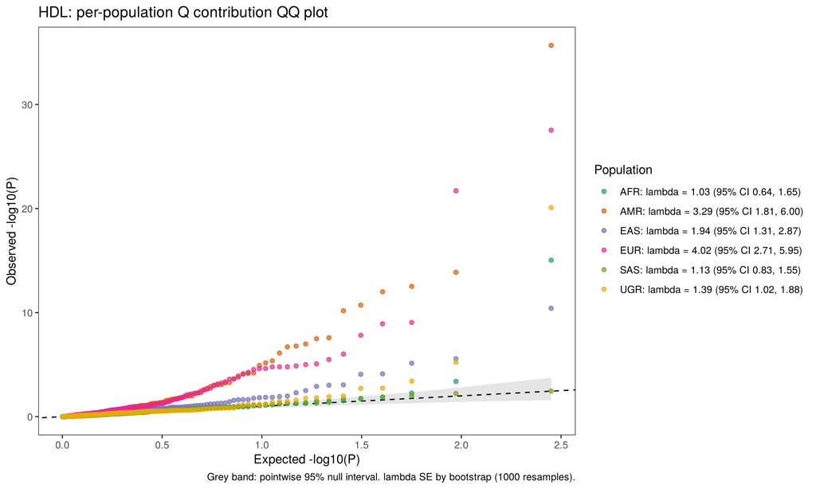

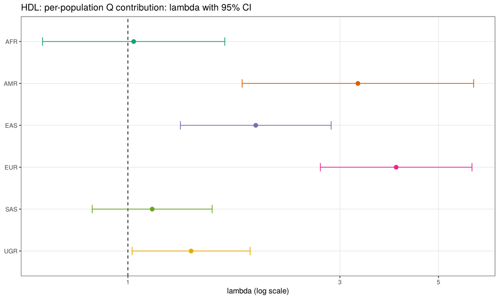

Genomic inflation (lambda) by population with standard error, 95% CI and Wald test of lambda = 1 (CI and test on the log scale; estimates from fewer than ~50 SNPs are imprecise)

| Population | n_snps | lambda | lambda_se | lambda_lci | lambda_uci | p_lambda_eq_1 |
| --- | --- | --- | --- | --- | --- | --- |
| AFR | 141 | 1.030 | 0.248 | 0.643 | 1.652 | 0.901 |
| AMR | 141 | 3.294 | 1.008 | 1.808 | 6.000 | 0.000 |
| EAS | 141 | 1.940 | 0.387 | 1.313 | 2.867 | 0.001 |
| EUR | 141 | 4.016 | 0.805 | 2.711 | 5.949 | 0.000 |
| SAS | 141 | 1.134 | 0.180 | 0.831 | 1.547 | 0.427 |
| UGR | 141 | 1.388 | 0.217 | 1.022 | 1.884 | 0.036 |

**Population-specific estimates for Bonferroni-significant SNPs**

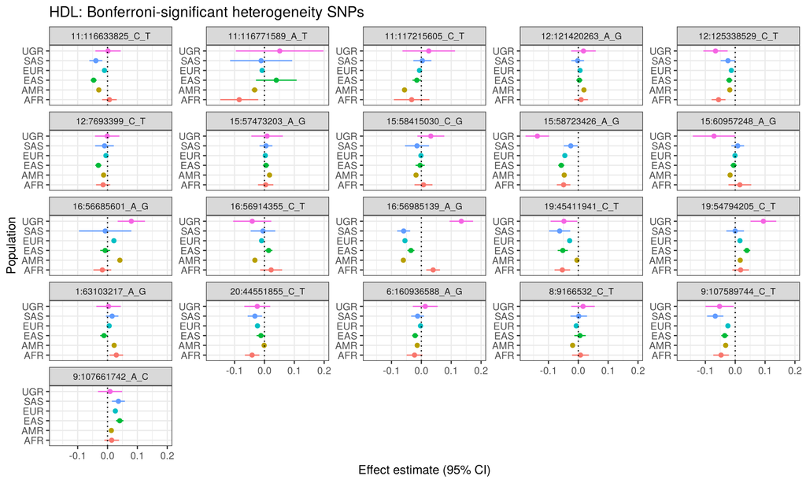

**Population-level Q contribution summary**

| population | variants_with_estimate | fraction_contribution_p_lt_0_05 |
| --- | --- | --- |
| AMR | 141 | 0.333 |
| EUR | 141 | 0.312 |
| EAS | 141 | 0.156 |
| UGR | 141 | 0.092 |
| AFR | 141 | 0.064 |
| SAS | 141 | 0.050 |

### 3.2.1 Expected versus observed replication: all exposure SNPs

EUR discovery SNPs with p < 5e-08; replication significance alpha = 0.05

| comparison | n_discovery | n_paired | nsnp | metric | datum | value | pdiff |
| --- | --- | --- | --- | --- | --- | --- | --- |
| EUR vs AFR | 121 | 121 | 121 | Sign | Expected | 87.70581 | NA |
| EUR vs AFR | 121 | 121 | 121 | Sign | Observed | 93.00000 | 0.30962 |
| EUR vs AFR | 121 | 121 | 121 | P-value | Expected | 16.47729 | NA |
| EUR vs AFR | 121 | 121 | 121 | P-value | Observed | 16.00000 | 1.00000 |
| EUR vs AMR | 121 | 121 | 121 | Sign | Expected | 120.01924 | NA |
| EUR vs AMR | 121 | 121 | 121 | Sign | Observed | 120.00000 | 0.62647 |
| EUR vs AMR | 121 | 121 | 121 | P-value | Expected | 95.40612 | NA |
| EUR vs AMR | 121 | 121 | 121 | P-value | Observed | 99.00000 | 0.50404 |
| EUR vs EAS | 121 | 121 | 121 | Sign | Expected | 106.52123 | NA |
| EUR vs EAS | 121 | 121 | 121 | Sign | Observed | 102.00000 | 0.20671 |
| EUR vs EAS | 121 | 121 | 121 | P-value | Expected | 40.21018 | NA |
| EUR vs EAS | 121 | 121 | 121 | P-value | Observed | 39.00000 | 0.84759 |
| EUR vs SAS | 121 | 121 | 121 | Sign | Expected | 91.56341 | NA |
| EUR vs SAS | 121 | 121 | 121 | Sign | Observed | 85.00000 | 0.16874 |
| EUR vs SAS | 121 | 121 | 121 | P-value | Expected | 18.06155 | NA |
| EUR vs SAS | 121 | 121 | 121 | P-value | Observed | 23.00000 | 0.20273 |
| EUR vs UGR | 121 | 121 | 121 | Sign | Expected | 78.23490 | NA |
| EUR vs UGR | 121 | 121 | 121 | Sign | Observed | 83.00000 | 0.39310 |
| EUR vs UGR | 121 | 121 | 121 | P-value | Expected | 10.26044 | NA |
| EUR vs UGR | 121 | 121 | 121 | P-value | Observed | 15.00000 | 0.13866 |

**Variants with expected-but-not-observed replication**

| comparison | snpid | expected_power | observed_sig | replication_fail | expected_sign | observed_sign | sign_fail |
| --- | --- | --- | --- | --- | --- | --- | --- |
| EUR vs AFR | 16:56985139_A_G | 0.99683 | TRUE | FALSE | 1.00000 | FALSE | TRUE |
| EUR vs AMR | 15:41888918_A_G | 0.57269 | FALSE | FALSE | 0.98395 | FALSE | TRUE |
| EUR vs AMR | 17:41837264_C_G | 0.99995 | FALSE | TRUE | 1.00000 | TRUE | FALSE |
| EUR vs AMR | 19:45411941_C_T | 1.00000 | FALSE | TRUE | 1.00000 | TRUE | FALSE |
| EUR vs AMR | 1:40043772_A_G | 0.99208 | FALSE | TRUE | 0.99999 | TRUE | FALSE |
| EUR vs AMR | 20:44551855_C_T | 0.99986 | FALSE | TRUE | 1.00000 | TRUE | FALSE |
| EUR vs AMR | 8:144296480_C_G | 0.99853 | FALSE | TRUE | 1.00000 | TRUE | FALSE |
| EUR vs AMR | 8:19955606_A_G | 0.99165 | FALSE | TRUE | 0.99999 | TRUE | FALSE |
| EUR vs EAS | 16:56685601_A_G | 0.71340 | FALSE | FALSE | 0.99419 | FALSE | TRUE |
| EUR vs EAS | 1:230297136_C_T | 0.95366 | FALSE | TRUE | 0.99986 | TRUE | FALSE |
| EUR vs UGR | 16:56985139_A_G | 0.77878 | TRUE | FALSE | 0.99681 | FALSE | TRUE |

### 3.2.2 Drug-target subset heterogeneity

Tests: 8; Bonferroni threshold: 0.00625; significant SNPs: 1

**Summary by drug class**

| Drug | n_snps | n_nominal_Q_p_lt_0_05 | n_bonferroni_significant | proportion_FDR_lt_0_05 | median_Q_p | median_FDR | min_FDR |
| --- | --- | --- | --- | --- | --- | --- | --- |
| Statins | 6 | 1 | 1 | 0.1667 | 0.3879 | 0.6852 | 0.0045 |
| Ezetimibe | 2 | 0 | 0 | 0.0000 | 0.3727 | 0.5039 | 0.2182 |

**Drug-target SNPs passing this subset’s Bonferroni threshold**

| snpid | Drug | n_pop | beta_fixed | se_fixed | Q | Qdf | Qpval | fdr |
| --- | --- | --- | --- | --- | --- | --- | --- | --- |
| 5:74649498_C_T | Statins | 6 | -0.00358 | 0.00083 | 21.81184 | 5 | 0.00057 | 0.00455 |

**Nominal drug-target heterogeneity: per-population Q contributions**

| AFR | AMR | EAS | EUR | SAS | UGR | snpid | Drug |
| --- | --- | --- | --- | --- | --- | --- | --- |
| 0.2971 | 0.08747 | 0.01483 | 0.01428 | 0.16927 | 0.0018 | 5:74649498_C_T | Statins |

**Drug-target per-population Q contribution plot**

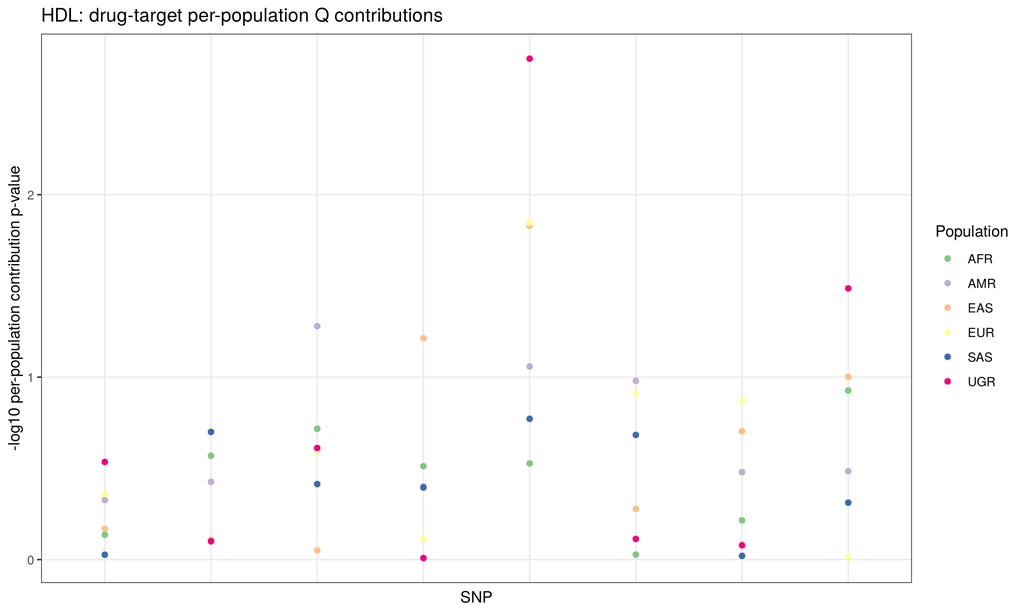

**Drug-target QQ plot and genomic inflation estimates**

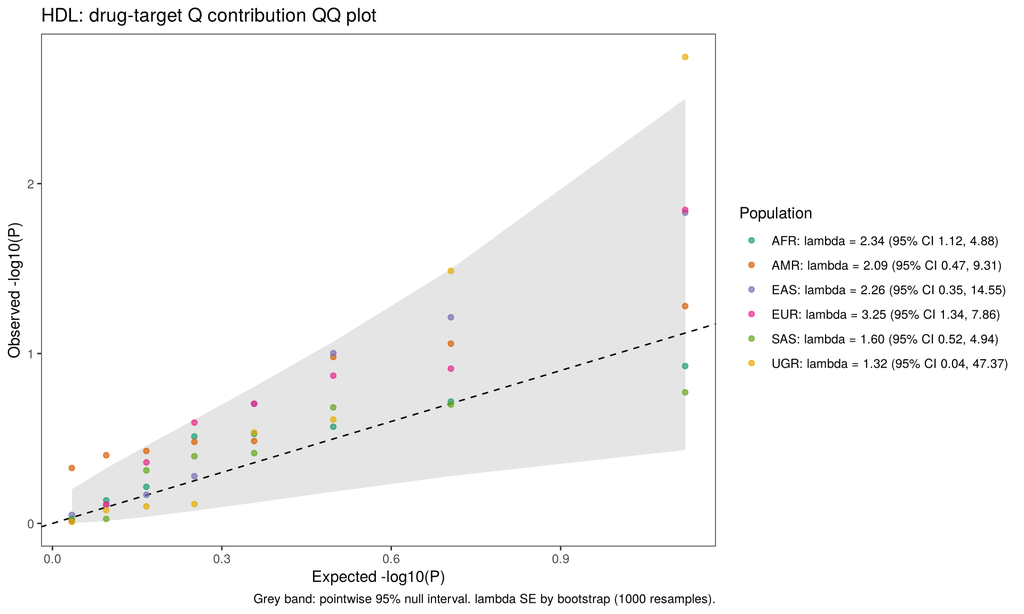

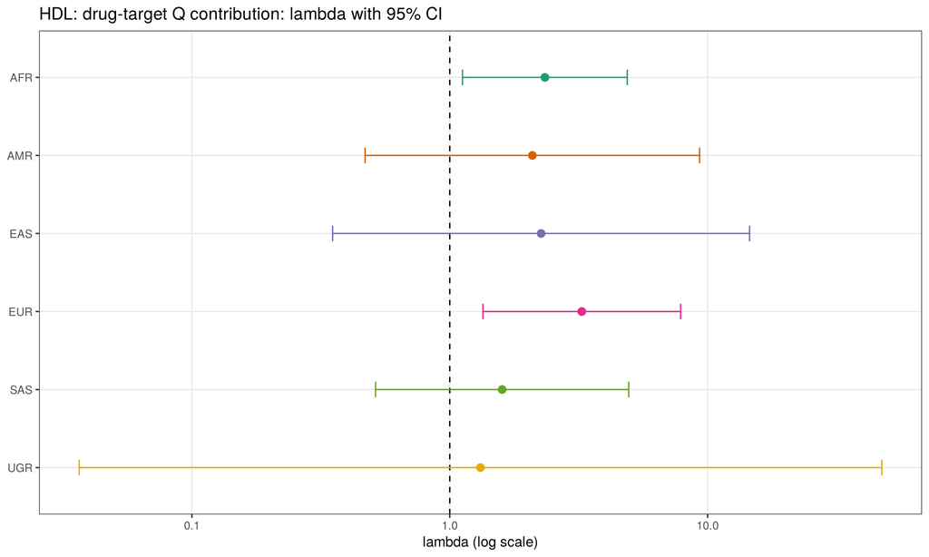

Genomic inflation (lambda) by population with standard error, 95% CI and Wald test of lambda = 1 (CI and test on the log scale; estimates from fewer than ~50 SNPs are imprecise)

| Population | n_snps | lambda | lambda_se | lambda_lci | lambda_uci | p_lambda_eq_1 |
| --- | --- | --- | --- | --- | --- | --- |
| AFR | 8 | 2.338 | 0.878 | 1.120 | 4.879 | 0.024 |
| AMR | 8 | 2.091 | 1.593 | 0.469 | 9.310 | 0.333 |
| EAS | 8 | 2.261 | 2.148 | 0.351 | 14.552 | 0.390 |
| EUR | 8 | 3.252 | 1.465 | 1.345 | 7.862 | 0.009 |
| SAS | 8 | 1.596 | 0.921 | 0.515 | 4.945 | 0.418 |
| UGR | 8 | 1.316 | 2.406 | 0.037 | 47.373 | 0.881 |

**Population-specific estimates for drug-target Bonferroni hits**

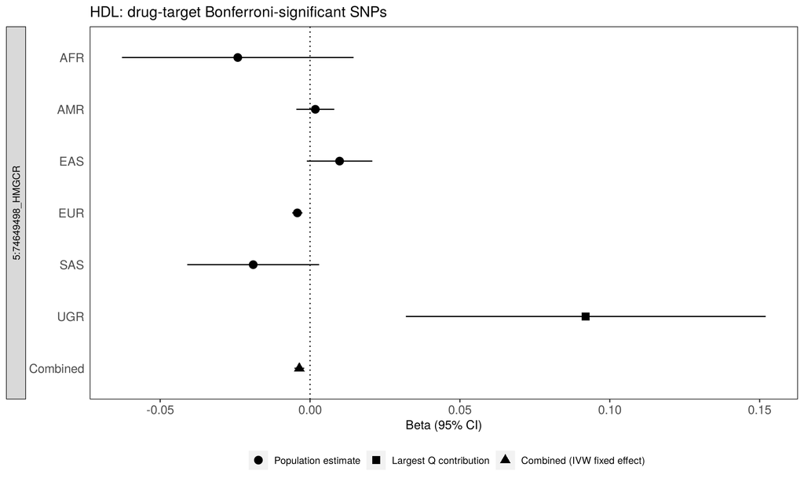

**Per-population Q contribution fractions by drug class**

| Drug | population | variants_with_estimate | fraction_contribution_p_lt_0_05 |
| --- | --- | --- | --- |
| Ezetimibe | UGR | 2 | 0.500 |
| Ezetimibe | AFR | 2 | 0.000 |
| Ezetimibe | AMR | 2 | 0.000 |
| Ezetimibe | EAS | 2 | 0.000 |
| Ezetimibe | EUR | 2 | 0.000 |
| Ezetimibe | SAS | 2 | 0.000 |
| Statins | EAS | 6 | 0.167 |
| Statins | EUR | 6 | 0.167 |
| Statins | UGR | 6 | 0.167 |
| Statins | AFR | 6 | 0.000 |
| Statins | AMR | 6 | 0.000 |
| Statins | SAS | 6 | 0.000 |

### 3.2.3 Expected versus observed replication: drug-target SNPs

Drug-target EUR discovery SNPs with p < 0.05; replication significance alpha = 0.05

| comparison | n_discovery | n_paired | nsnp | metric | datum | value | pdiff |
| --- | --- | --- | --- | --- | --- | --- | --- |
| EUR vs AFR | 3 | 3 | 3 | Sign | Expected | 1.70463 | NA |
| EUR vs AFR | 3 | 3 | 3 | Sign | Observed | 1.00000 | 0.58177 |
| EUR vs AFR | 3 | 3 | 3 | P-value | Expected | 0.16151 | NA |
| EUR vs AFR | 3 | 3 | 3 | P-value | Observed | 0.00000 | 1.00000 |
| EUR vs AMR | 3 | 3 | 3 | Sign | Expected | 2.41897 | NA |
| EUR vs AMR | 3 | 3 | 3 | Sign | Observed | 0.00000 | 0.00726 |
| EUR vs AMR | 3 | 3 | 3 | P-value | Expected | 0.47821 | NA |
| EUR vs AMR | 3 | 3 | 3 | P-value | Observed | 0.00000 | 1.00000 |
| EUR vs EAS | 3 | 3 | 3 | Sign | Expected | 1.99528 | NA |
| EUR vs EAS | 3 | 3 | 3 | Sign | Observed | 1.00000 | 0.26136 |
| EUR vs EAS | 3 | 3 | 3 | P-value | Expected | 0.23701 | NA |
| EUR vs EAS | 3 | 3 | 3 | P-value | Observed | 0.00000 | 1.00000 |
| EUR vs SAS | 3 | 3 | 3 | Sign | Expected | 1.75806 | NA |
| EUR vs SAS | 3 | 3 | 3 | Sign | Observed | 2.00000 | 1.00000 |
| EUR vs SAS | 3 | 3 | 3 | P-value | Expected | 0.17113 | NA |
| EUR vs SAS | 3 | 3 | 3 | P-value | Observed | 0.00000 | 1.00000 |
| EUR vs UGR | 3 | 3 | 3 | Sign | Expected | 1.62582 | NA |
| EUR vs UGR | 3 | 3 | 3 | Sign | Observed | 0.00000 | 0.09611 |
| EUR vs UGR | 3 | 3 | 3 | P-value | Expected | 0.15443 | NA |
| EUR vs UGR | 3 | 3 | 3 | P-value | Observed | 1.00000 | 0.14661 |

## 3.3 LDLC

**Variant counts by population**

| population | variants |
| --- | --- |
| AFR | 297 |
| AMR | 297 |
| EAS | 297 |
| EUR | 297 |
| SAS | 297 |
| UGR | 297 |

**Overall heterogeneity summary**

| variants_tested | bonferroni_threshold | nominal_Q_p_lt_0_05 | bonferroni_significant | FDR_lt_0_05 | smallest_Q_p | smallest_FDR |
| --- | --- | --- | --- | --- | --- | --- |
| 297 | 0.00017 | 126 | 37 | 99 | 0 | 0 |

**Transferability versus EUR (SNPs oriented to the EUR effect-increasing allele)**

| pop | n_snps | ivw_slope | ivw_slope_se | ivw_slope_lci | ivw_slope_uci | sign_concordance | pearson_r |
| --- | --- | --- | --- | --- | --- | --- | --- |
| AFR | 297 | 1.288 | 0.066 | 1.158 | 1.418 | 0.707 | 0.320 |
| AMR | 297 | 1.251 | 0.030 | 1.193 | 1.309 | 0.929 | 0.467 |
| EAS | 297 | 1.057 | 0.021 | 1.015 | 1.099 | 0.838 | 0.638 |
| SAS | 297 | 1.533 | 0.124 | 1.290 | 1.777 | 0.636 | 0.326 |
| UGR | 297 | 0.929 | 0.063 | 0.806 | 1.052 | 0.680 | 0.219 |

**SNPs passing this trait’s Bonferroni threshold**

| snpid | n_pop | beta_fixed | se_fixed | Q | Qdf | Qpval | fdr |
| --- | --- | --- | --- | --- | --- | --- | --- |
| 19:45387034_A_C | 6 | 0.27420 | 0.00411 | 294.19824 | 5 | 0.00000 | 0.00000 |
| 11:116648917_C_G | 6 | -0.05508 | 0.00246 | 217.29540 | 5 | 0.00000 | 0.00000 |
| 19:45233385_A_G | 6 | 0.14511 | 0.00299 | 202.54230 | 5 | 0.00000 | 0.00000 |
| 1:109817590_G_T | 6 | 0.11658 | 0.00207 | 172.45538 | 5 | 0.00000 | 0.00000 |
| 16:56993324_A_C | 6 | -0.02654 | 0.00184 | 140.57640 | 5 | 0.00000 | 0.00000 |
| 1:55520445_A_G | 6 | 0.03188 | 0.00415 | 80.89235 | 5 | 0.00000 | 0.00000 |
| 11:61557826_C_T | 6 | -0.03205 | 0.00180 | 72.70529 | 5 | 0.00000 | 0.00000 |
| 19:11177777_C_T | 6 | 0.02143 | 0.00379 | 60.60739 | 5 | 0.00000 | 0.00000 |
| 1:55518682_C_T | 6 | 0.03827 | 0.00185 | 54.17055 | 5 | 0.00000 | 0.00000 |
| 19:11227480_A_C | 6 | -0.04013 | 0.00173 | 53.56663 | 5 | 0.00000 | 0.00000 |
| 1:55519231_A_T | 6 | 0.03108 | 0.00418 | 51.96288 | 5 | 0.00000 | 0.00000 |
| 1:55517940_A_G | 6 | -0.03013 | 0.00423 | 51.11418 | 5 | 0.00000 | 0.00000 |
| 1:55519068_A_T | 6 | 0.03258 | 0.00409 | 50.40635 | 5 | 0.00000 | 0.00000 |
| 1:55520864_A_G | 6 | -0.02496 | 0.00220 | 47.46324 | 5 | 0.00000 | 0.00000 |
| 1:55524842_A_G | 6 | 0.01503 | 0.00188 | 47.00022 | 5 | 0.00000 | 0.00000 |
| 1:55527323_A_G | 6 | 0.01454 | 0.00188 | 46.45860 | 5 | 0.00000 | 0.00000 |
| 16:72217113_G_T | 6 | -0.02107 | 0.00203 | 45.92745 | 5 | 0.00000 | 0.00000 |
| 1:55518828_A_G | 6 | 0.03072 | 0.00418 | 44.95552 | 5 | 0.00000 | 0.00000 |
| 15:58723675_C_T | 6 | -0.01880 | 0.00205 | 42.18703 | 5 | 0.00000 | 0.00000 |
| 1:55521195_C_T | 6 | 0.04510 | 0.00334 | 41.38508 | 5 | 0.00000 | 0.00000 |
| 1:55520265_C_T | 6 | 0.03410 | 0.00196 | 41.23825 | 5 | 0.00000 | 0.00000 |
| 1:55526296_A_G | 6 | -0.01514 | 0.00188 | 41.16486 | 5 | 0.00000 | 0.00000 |
| 1:55529828_C_T | 6 | -0.00247 | 0.00200 | 38.86399 | 5 | 0.00000 | 0.00000 |
| 11:61687033_A_G | 6 | -0.00906 | 0.00174 | 36.96286 | 5 | 0.00000 | 0.00001 |
| 1:55518160_A_C | 6 | -0.02036 | 0.00381 | 31.99676 | 5 | 0.00001 | 0.00007 |
| 1:55517344_C_T | 6 | -0.01605 | 0.00182 | 31.43857 | 5 | 0.00001 | 0.00009 |
| 8:126500031_C_G | 6 | 0.05952 | 0.00177 | 29.91486 | 5 | 0.00002 | 0.00017 |
| 1:55518528_A_C | 6 | 0.03681 | 0.00183 | 29.22421 | 5 | 0.00002 | 0.00022 |
| 1:55519238_C_T | 6 | -0.03743 | 0.00187 | 28.73828 | 5 | 0.00003 | 0.00027 |
| 19:19379549_C_T | 6 | 0.09083 | 0.00325 | 27.33112 | 5 | 0.00005 | 0.00049 |
| 1:55518198_A_C | 6 | 0.01087 | 0.00250 | 25.98606 | 5 | 0.00009 | 0.00086 |
| 1:55513725_A_T | 6 | 0.01174 | 0.00221 | 25.44420 | 5 | 0.00011 | 0.00105 |
| 1:55514046_G_T | 6 | -0.01169 | 0.00222 | 25.40703 | 5 | 0.00012 | 0.00105 |
| 5:74648496_G_T | 6 | -0.04877 | 0.00204 | 25.03285 | 5 | 0.00014 | 0.00120 |
| 20:17844492_G_T | 6 | 0.02460 | 0.00180 | 24.91813 | 5 | 0.00014 | 0.00123 |
| 1:55518316_C_T | 6 | 0.02889 | 0.00177 | 24.75884 | 5 | 0.00016 | 0.00128 |
| 5:74653462_G_T | 6 | 0.04761 | 0.00197 | 24.58382 | 5 | 0.00017 | 0.00132 |

**Nominally heterogeneous SNPs (Q p < 0.05): per-population Q contributions**

| AFR | AMR | EAS | EUR | SAS | UGR | snpid |
| --- | --- | --- | --- | --- | --- | --- |
| 0.37207 | 0.06301 | 0.00374 | 0.00041 | 0.64452 | 0.78591 | 10:113940329_C_T |
| 0.06653 | 0.00000 | 0.00000 | 0.00000 | 0.05485 | 0.02360 | 11:116648917_C_G |
| 0.15020 | 0.00206 | 0.01139 | 0.90274 | 0.32281 | 0.27347 | 11:18632984_C_T |
| 0.48546 | 0.00000 | 0.56976 | 0.00000 | 0.04448 | 0.38866 | 11:61557826_C_T |
| 0.31481 | 0.00000 | 0.27732 | 0.00000 | 0.23368 | 0.03412 | 11:61687033_A_G |
| 0.93155 | 0.00035 | 0.71666 | 0.05561 | 0.46881 | 0.98468 | 14:70756333_A_G |
| 0.31439 | 0.00612 | 0.58261 | 0.18842 | 0.23782 | 0.03900 | 14:75299101_A_G |
| 0.01440 | 0.76879 | 0.00000 | 0.00023 | 0.08701 | 0.93244 | 15:58723675_C_T |
| 0.14476 | 0.00000 | 0.00000 | 0.00000 | 0.92705 | 0.63136 | 16:56993324_A_C |
| 0.00011 | 0.00796 | 0.00008 | 0.00054 | 0.00580 | 0.35225 | 16:72217113_G_T |
| 0.82227 | 0.00013 | 0.86478 | 0.01136 | 0.99407 | 0.71311 | 16:83983775_C_T |
| 0.00389 | 0.07117 | 0.36722 | 0.02118 | 0.09026 | 0.62160 | 17:26694861_A_G |
| 0.32569 | 0.12132 | 0.83045 | 0.19015 | 0.08779 | 0.00602 | 17:45633485_C_T |
| 0.15902 | 0.30320 | 0.00037 | 0.00025 | 0.60937 | 0.39182 | 17:67052472_G_T |
| 0.74464 | 0.00591 | 0.39810 | 0.00777 | 0.21557 | 0.07273 | 17:7080316_C_T |
| 0.00000 | 0.39697 | 0.00090 | 0.02220 | 0.06935 | 0.00000 | 19:11177777_C_T |
| 0.00064 | 0.01651 | 0.82110 | 0.00011 | 0.47118 | 0.11331 | 19:11187324_C_G |
| 0.37253 | 0.00052 | 0.00000 | 0.00024 | 0.38952 | 0.45986 | 19:11227480_A_C |
| 0.00035 | 0.27671 | 0.78355 | 0.04215 | 0.13593 | 0.12605 | 19:11335477_A_C |
| 0.70663 | 0.11981 | 0.00000 | 0.00000 | 0.71654 | 0.52547 | 19:19379549_C_T |
| 0.00003 | 0.12628 | 0.00000 | 0.00000 | 0.78265 | 0.00001 | 19:45233385_A_G |
| 0.17379 | 0.00000 | 0.00000 | 0.00002 | 0.00623 | 0.00045 | 19:45387034_A_C |
| 0.94654 | 0.00127 | 0.01637 | 0.00014 | 0.42817 | 0.21849 | 19:45500712_C_T |
| 0.00228 | 0.00000 | 0.00050 | 0.00000 | 0.00035 | 0.00000 | 1:109817590_G_T |
| 0.07953 | 0.10360 | 0.02898 | 0.00203 | 0.36015 | 0.73709 | 1:220970028_A_G |
| 0.15780 | 0.25079 | 0.06168 | 0.23345 | 0.07812 | 0.07145 | 1:234847814_G_T |
| 0.14762 | 0.11789 | 0.00076 | 0.02625 | 0.68330 | 0.05351 | 1:55505732_A_G |
| 0.65656 | 0.21227 | 0.01058 | 0.00346 | 0.68255 | 0.05839 | 1:55507649_C_T |
| 0.75666 | 0.16711 | 0.01034 | 0.00042 | 0.45605 | 0.00096 | 1:55507882_C_T |
| 0.08811 | 0.18089 | 0.00055 | 0.02633 | 0.69188 | 0.09960 | 1:55508186_A_T |

[output cut: 96 more lines]

**Per-population Q contribution plot** (method: loo)

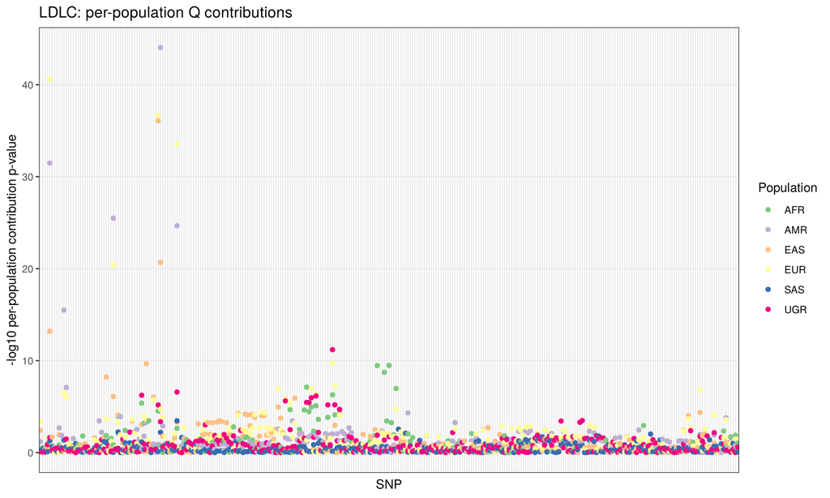

**QQ plot and genomic inflation estimates for per-population Q contributions**

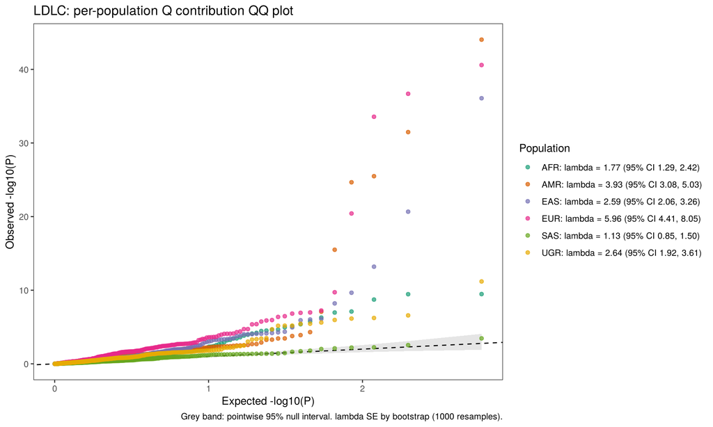

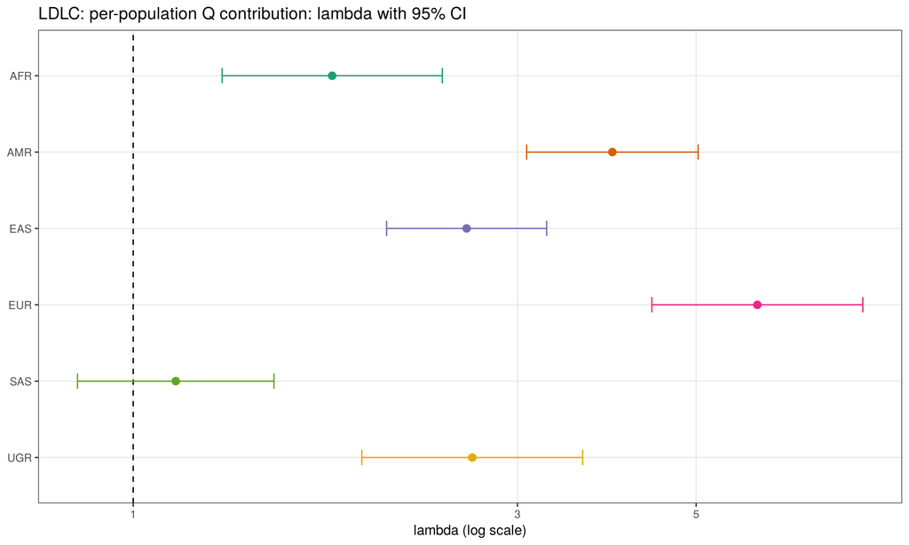

Genomic inflation (lambda) by population with standard error, 95% CI and Wald test of lambda = 1 (CI and test on the log scale; estimates from fewer than ~50 SNPs are imprecise)

| Population | n_snps | lambda | lambda_se | lambda_lci | lambda_uci | p_lambda_eq_1 |
| --- | --- | --- | --- | --- | --- | --- |
| AFR | 297 | 1.766 | 0.284 | 1.289 | 2.420 | 0.000 |
| AMR | 297 | 3.935 | 0.492 | 3.079 | 5.028 | 0.000 |
| EAS | 297 | 2.594 | 0.303 | 2.064 | 3.261 | 0.000 |
| EUR | 297 | 5.956 | 0.916 | 4.405 | 8.052 | 0.000 |
| SAS | 297 | 1.129 | 0.162 | 0.853 | 1.495 | 0.396 |
| UGR | 297 | 2.636 | 0.425 | 1.922 | 3.615 | 0.000 |

**Population-specific estimates for Bonferroni-significant SNPs**

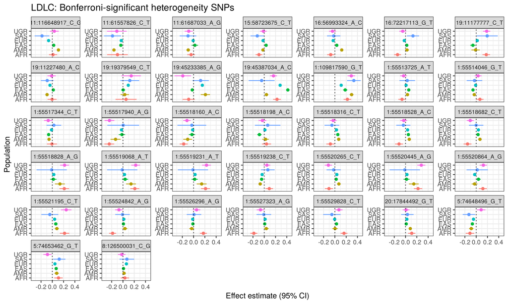

**Population-level Q contribution summary**

| population | variants_with_estimate | fraction_contribution_p_lt_0_05 |
| --- | --- | --- |
| EUR | 297 | 0.424 |
| AMR | 297 | 0.256 |
| EAS | 297 | 0.249 |
| UGR | 297 | 0.236 |
| AFR | 297 | 0.182 |
| SAS | 297 | 0.067 |

### 3.3.1 Expected versus observed replication: all exposure SNPs

EUR discovery SNPs with p < 5e-08; replication significance alpha = 0.05

| comparison | n_discovery | n_paired | nsnp | metric | datum | value | pdiff |
| --- | --- | --- | --- | --- | --- | --- | --- |
| EUR vs AFR | 241 | 241 | 241 | Sign | Expected | 173.42652 | NA |
| EUR vs AFR | 241 | 241 | 241 | Sign | Observed | 185.00000 | 0.09945 |
| EUR vs AFR | 241 | 241 | 241 | P-value | Expected | 30.46489 | NA |
| EUR vs AFR | 241 | 241 | 241 | P-value | Observed | 71.00000 | 0.00000 |
| EUR vs AMR | 241 | 241 | 241 | Sign | Expected | 212.36472 | NA |
| EUR vs AMR | 241 | 241 | 241 | Sign | Observed | 234.00000 | 0.00000 |
| EUR vs AMR | 241 | 241 | 241 | P-value | Expected | 85.84403 | NA |
| EUR vs AMR | 241 | 241 | 241 | P-value | Observed | 134.00000 | 0.00000 |
| EUR vs EAS | 241 | 241 | 241 | Sign | Expected | 223.23088 | NA |
| EUR vs EAS | 241 | 241 | 241 | Sign | Observed | 211.00000 | 0.00612 |
| EUR vs EAS | 241 | 241 | 241 | P-value | Expected | 120.06383 | NA |
| EUR vs EAS | 241 | 241 | 241 | P-value | Observed | 113.00000 | 0.36794 |
| EUR vs SAS | 241 | 241 | 241 | Sign | Expected | 156.78721 | NA |
| EUR vs SAS | 241 | 241 | 241 | Sign | Observed | 160.00000 | 0.68580 |
| EUR vs SAS | 241 | 241 | 241 | P-value | Expected | 19.53933 | NA |
| EUR vs SAS | 241 | 241 | 241 | P-value | Observed | 42.00000 | 0.00000 |
| EUR vs UGR | 241 | 241 | 241 | Sign | Expected | 175.01937 | NA |
| EUR vs UGR | 241 | 241 | 241 | Sign | Observed | 178.00000 | 0.71812 |
| EUR vs UGR | 241 | 241 | 241 | P-value | Expected | 31.55770 | NA |
| EUR vs UGR | 241 | 241 | 241 | P-value | Observed | 65.00000 | 0.00000 |

**Variants with expected-but-not-observed replication**

| comparison | snpid | expected_power | observed_sig | replication_fail | expected_sign | observed_sign | sign_fail |
| --- | --- | --- | --- | --- | --- | --- | --- |
| EUR vs AFR | 11:116648917_C_G | 0.42746 | FALSE | FALSE | 0.96221 | FALSE | TRUE |
| EUR vs AFR | 19:45233385_A_G | 0.79153 | FALSE | FALSE | 0.99721 | FALSE | TRUE |
| EUR vs AMR | 11:116648917_C_G | 0.99647 | TRUE | FALSE | 1.00000 | FALSE | TRUE |
| EUR vs AMR | 16:56993324_A_C | 0.57681 | TRUE | FALSE | 0.98437 | FALSE | TRUE |
| EUR vs AMR | 19:45500712_C_T | 0.43348 | FALSE | FALSE | 0.96345 | FALSE | TRUE |
| EUR vs AMR | 1:63086001_A_T | 0.77016 | FALSE | FALSE | 0.99653 | FALSE | TRUE |
| EUR vs AMR | 8:126500031_C_G | 0.97585 | FALSE | TRUE | 0.99996 | TRUE | FALSE |
| EUR vs EAS | 11:116648917_C_G | 0.99997 | TRUE | FALSE | 1.00000 | FALSE | TRUE |
| EUR vs EAS | 11:18632984_C_T | 0.47653 | FALSE | FALSE | 0.97135 | FALSE | TRUE |
| EUR vs EAS | 15:58723675_C_T | 0.61928 | TRUE | FALSE | 0.98820 | FALSE | TRUE |
| EUR vs EAS | 16:56993324_A_C | 0.69240 | TRUE | FALSE | 0.99310 | FALSE | TRUE |
| EUR vs EAS | 16:72217113_G_T | 0.52864 | TRUE | FALSE | 0.97891 | FALSE | TRUE |
| EUR vs EAS | 17:67052472_G_T | 0.97282 | FALSE | TRUE | 0.99995 | TRUE | FALSE |
| EUR vs EAS | 19:11227480_A_C | 0.99421 | FALSE | TRUE | 1.00000 | FALSE | TRUE |
| EUR vs EAS | 19:19379549_C_T | 0.99945 | FALSE | TRUE | 1.00000 | TRUE | FALSE |
| EUR vs EAS | 19:45233385_A_G | 1.00000 | FALSE | TRUE | 1.00000 | FALSE | TRUE |
| EUR vs EAS | 19:45636201_C_T | 0.37918 | FALSE | FALSE | 0.95072 | FALSE | TRUE |
| EUR vs EAS | 6:25694684_C_T | 0.38532 | FALSE | FALSE | 0.95235 | FALSE | TRUE |
| EUR vs EAS | 7:44579180_C_G | 0.81919 | FALSE | FALSE | 0.99796 | FALSE | TRUE |
| EUR vs EAS | 7:44581986_C_T | 0.96003 | FALSE | TRUE | 0.99990 | FALSE | TRUE |
| EUR vs EAS | 8:126500031_C_G | 0.99886 | FALSE | TRUE | 1.00000 | TRUE | FALSE |
| EUR vs EAS | 8:18272635_C_T | 0.63871 | FALSE | FALSE | 0.98969 | FALSE | TRUE |
| EUR vs SAS | 19:45387034_A_C | 0.67070 | FALSE | FALSE | 0.99184 | FALSE | TRUE |
| EUR vs UGR | 19:45233385_A_G | 0.54216 | TRUE | FALSE | 0.98058 | FALSE | TRUE |
| EUR vs UGR | 8:126500031_C_G | 0.43160 | FALSE | FALSE | 0.96307 | FALSE | TRUE |

### 3.3.2 Drug-target subset heterogeneity

Tests: 138; Bonferroni threshold: 0.00036232; significant SNPs: 27

**Summary by drug class**

| Drug | n_snps | n_nominal_Q_p_lt_0_05 | n_bonferroni_significant | proportion_FDR_lt_0_05 | median_Q_p | median_FDR | min_FDR |
| --- | --- | --- | --- | --- | --- | --- | --- |
| Statins | 125 | 78 | 27 | 0.536 | 0.0095 | 0.0208 | 0.000 |
| Ezetimibe | 13 | 1 | 0 | 0.000 | 0.4639 | 0.5061 | 0.061 |

**Drug-target SNPs passing this subset’s Bonferroni threshold**

| snpid | Drug | n_pop | beta_fixed | se_fixed | Q | Qdf | Qpval | fdr |
| --- | --- | --- | --- | --- | --- | --- | --- | --- |
| 1:55520445_A_G | Statins | 6 | 0.03188 | 0.00415 | 80.89235 | 5 | 0.00000 | 0.00000 |
| 1:55518682_C_T | Statins | 6 | 0.03827 | 0.00185 | 54.17055 | 5 | 0.00000 | 0.00000 |
| 1:55519231_A_T | Statins | 6 | 0.03108 | 0.00418 | 51.96288 | 5 | 0.00000 | 0.00000 |
| 1:55517940_A_G | Statins | 6 | -0.03013 | 0.00423 | 51.11418 | 5 | 0.00000 | 0.00000 |
| 1:55519068_A_T | Statins | 6 | 0.03258 | 0.00409 | 50.40635 | 5 | 0.00000 | 0.00000 |
| 1:55520864_A_G | Statins | 6 | -0.02496 | 0.00220 | 47.46324 | 5 | 0.00000 | 0.00000 |
| 1:55524842_A_G | Statins | 6 | 0.01503 | 0.00188 | 47.00022 | 5 | 0.00000 | 0.00000 |
| 1:55527323_A_G | Statins | 6 | 0.01454 | 0.00188 | 46.45860 | 5 | 0.00000 | 0.00000 |
| 1:55518828_A_G | Statins | 6 | 0.03072 | 0.00418 | 44.95552 | 5 | 0.00000 | 0.00000 |
| 1:55521195_C_T | Statins | 6 | 0.04510 | 0.00334 | 41.38508 | 5 | 0.00000 | 0.00000 |
| 1:55520265_C_T | Statins | 6 | 0.03410 | 0.00196 | 41.23825 | 5 | 0.00000 | 0.00000 |
| 1:55526296_A_G | Statins | 6 | -0.01514 | 0.00188 | 41.16486 | 5 | 0.00000 | 0.00000 |
| 1:55529828_C_T | Statins | 6 | -0.00247 | 0.00200 | 38.86399 | 5 | 0.00000 | 0.00000 |
| 1:55518160_A_C | Statins | 6 | -0.02036 | 0.00381 | 31.99676 | 5 | 0.00001 | 0.00006 |
| 1:55517344_C_T | Statins | 6 | -0.01605 | 0.00182 | 31.43857 | 5 | 0.00001 | 0.00007 |
| 1:55518528_A_C | Statins | 6 | 0.03681 | 0.00183 | 29.22421 | 5 | 0.00002 | 0.00018 |
| 1:55519238_C_T | Statins | 6 | -0.03743 | 0.00187 | 28.73828 | 5 | 0.00003 | 0.00021 |
| 1:55518198_A_C | Statins | 6 | 0.01087 | 0.00250 | 25.98606 | 5 | 0.00009 | 0.00069 |
| 1:55513725_A_T | Statins | 6 | 0.01174 | 0.00221 | 25.44420 | 5 | 0.00011 | 0.00080 |
| 1:55514046_G_T | Statins | 6 | -0.01169 | 0.00222 | 25.40703 | 5 | 0.00012 | 0.00080 |
| 5:74648496_G_T | Statins | 6 | -0.04877 | 0.00204 | 25.03285 | 5 | 0.00014 | 0.00090 |
| 1:55518316_C_T | Statins | 6 | 0.02889 | 0.00177 | 24.75884 | 5 | 0.00016 | 0.00097 |
| 5:74653462_G_T | Statins | 6 | 0.04761 | 0.00197 | 24.58382 | 5 | 0.00017 | 0.00097 |
| 5:74652754_A_ATCCATCCGTCTGTCCG | Statins | 6 | 0.04766 | 0.00197 | 24.57110 | 5 | 0.00017 | 0.00097 |
| 1:55512549_C_T | Statins | 6 | 0.01119 | 0.00219 | 23.64491 | 5 | 0.00025 | 0.00140 |
| 1:55514182_C_T | Statins | 6 | 0.01194 | 0.00222 | 23.13392 | 5 | 0.00032 | 0.00169 |
| 5:74649498_C_T | Statins | 6 | -0.04903 | 0.00204 | 22.86494 | 5 | 0.00036 | 0.00183 |

**Nominal drug-target heterogeneity: per-population Q contributions**

| AFR | AMR | EAS | EUR | SAS | UGR | snpid | Drug |
| --- | --- | --- | --- | --- | --- | --- | --- |
| 0.14762 | 0.11789 | 0.00076 | 0.02625 | 0.68330 | 0.05351 | 1:55505732_A_G | Statins |
| 0.65656 | 0.21227 | 0.01058 | 0.00346 | 0.68255 | 0.05839 | 1:55507649_C_T | Statins |
| 0.75666 | 0.16711 | 0.01034 | 0.00042 | 0.45605 | 0.00096 | 1:55507882_C_T | Statins |
| 0.08811 | 0.18089 | 0.00055 | 0.02633 | 0.69188 | 0.09960 | 1:55508186_A_T | Statins |
| 0.08385 | 0.13934 | 0.00056 | 0.01730 | 0.68559 | 0.19750 | 1:55509355_C_T | Statins |
| 0.05008 | 0.44932 | 0.02286 | 0.85898 | 0.98994 | 0.01388 | 1:55509872_C_T | Statins |
| 0.09061 | 0.12618 | 0.00047 | 0.02496 | 0.68742 | 0.04203 | 1:55509900_C_T | Statins |
| 0.14352 | 0.12678 | 0.00034 | 0.01359 | 0.68728 | 0.10117 | 1:55509939_C_T | Statins |
| 0.11449 | 0.12753 | 0.00044 | 0.02142 | 0.64315 | 0.04717 | 1:55510274_A_AC | Statins |
| 0.05175 | 0.52661 | 0.02177 | 0.82976 | 0.96362 | 0.01088 | 1:55510813_C_CGAA | Statins |
| 0.07753 | 0.13530 | 0.00055 | 0.03139 | 0.68687 | 0.02726 | 1:55511068_C_T | Statins |
| 0.87434 | 0.25766 | 0.00894 | 0.00385 | 0.48252 | 0.06831 | 1:55511471_C_T | Statins |
| 0.37002 | 0.16034 | 0.01214 | 0.00181 | 0.31109 | 0.09764 | 1:55511623_T_TC | Statins |
| 0.00164 | 0.86599 | 0.31043 | 0.39442 | 0.71325 | 0.01557 | 1:55511995_A_G | Statins |
| 0.83646 | 0.03019 | 0.00005 | 0.00008 | 0.69326 | 0.15140 | 1:55512549_C_T | Statins |
| 0.05250 | 0.19177 | 0.00321 | 0.22359 | 0.54993 | 0.00392 | 1:55512995_A_G | Statins |
| 0.02357 | 0.13574 | 0.00007 | 0.00450 | 0.79318 | 0.13828 | 1:55513725_A_T | Statins |
| 0.01827 | 0.13365 | 0.00008 | 0.00533 | 0.79682 | 0.14580 | 1:55514046_G_T | Statins |
| 0.09358 | 0.05577 | 0.00123 | 0.00877 | 0.57015 | 0.19695 | 1:55514073_C_G | Statins |
| 0.04282 | 0.12375 | 0.00007 | 0.00212 | 0.79964 | 0.35847 | 1:55514182_C_T | Statins |
| 0.45165 | 0.13928 | 0.00015 | 0.00008 | 0.79152 | 0.86362 | 1:55514215_G_T | Statins |
| 0.45364 | 0.11895 | 0.00010 | 0.00004 | 0.96120 | 0.66427 | 1:55515537_C_T | Statins |
| 0.85523 | 0.11786 | 0.00009 | 0.00005 | 0.81785 | 0.51178 | 1:55515668_C_CACG | Statins |
| 0.62142 | 0.14652 | 0.01264 | 0.00168 | 0.60324 | 0.08757 | 1:55516004_A_C | Statins |
| 0.47212 | 0.06775 | 0.00683 | 0.00270 | 0.43712 | 0.73981 | 1:55516508_A_G | Statins |
| 0.83531 | 0.00273 | 0.00001 | 0.00000 | 0.51313 | 0.15320 | 1:55517344_C_T | Statins |
| 0.24639 | 0.71826 | 0.00018 | 0.00337 | 0.72362 | 0.99524 | 1:55517861_C_G | Statins |
| 0.00000 | 0.02448 | 0.67986 | 0.00000 | 0.80939 | 0.00000 | 1:55517940_A_G | Statins |
| 0.00002 | 0.03413 | 0.75482 | 0.00000 | 0.93251 | 0.00328 | 1:55518160_A_C | Statins |
| 0.91472 | 0.00036 | 0.39867 | 0.02014 | 0.56663 | 0.23392 | 1:55518166_A_G | Statins |
| 0.47672 | 0.67749 | 0.00000 | 0.00062 | 0.66195 | 0.21386 | 1:55518198_A_C | Statins |
| 0.00297 | 0.00968 | 0.04192 | 0.11296 | 0.22013 | 0.05397 | 1:55518316_C_T | Statins |
| 0.00002 | 0.05579 | 0.22053 | 0.84587 | 0.23410 | 0.02697 | 1:55518528_A_C | Statins |
| 0.00000 | 0.06757 | 0.69492 | 0.04270 | 0.54764 | 0.00000 | 1:55518682_C_T | Statins |
| 0.00003 | 0.01917 | 0.66796 | 0.00000 | 0.76016 | 0.00000 | 1:55518828_A_G | Statins |
| 0.00001 | 0.01285 | 0.83266 | 0.00000 | 0.74194 | 0.00000 | 1:55519068_A_T | Statins |
| 0.00466 | 0.01725 | 0.43503 | 0.70631 | 0.13863 | 0.02156 | 1:55519174_A_G | Statins |
| 0.00001 | 0.01183 | 0.67303 | 0.00000 | 0.75811 | 0.00000 | 1:55519231_A_T | Statins |
| 0.00024 | 0.03070 | 0.43299 | 0.88956 | 0.09974 | 0.00638 | 1:55519238_C_T | Statins |
| 0.16654 | 0.00892 | 0.64439 | 0.02421 | 0.33054 | 0.13872 | 1:55520212_A_G | Statins |
| 0.00015 | 0.02285 | 0.41845 | 0.09696 | 0.38647 | 0.00001 | 1:55520265_C_T | Statins |
| 0.16980 | 0.01143 | 0.61530 | 0.02734 | 0.22167 | 0.14064 | 1:55520408_C_G | Statins |
| 0.00000 | 0.00908 | 0.60668 | 0.00000 | 0.74499 | 0.00000 | 1:55520445_A_G | Statins |
| 0.00008 | 0.88668 | 0.00105 | 0.00000 | 0.65075 | 0.00001 | 1:55520864_A_G | Statins |
| 0.86169 | 0.00916 | 0.98004 | 0.07782 | 0.31689 | 0.05168 | 1:55521109_A_G | Statins |
| 0.00006 | 0.05134 | 0.30565 | 0.00008 | 0.24615 | 0.00002 | 1:55521195_C_T | Statins |
| 0.92802 | 0.00934 | 0.95059 | 0.08490 | 0.33177 | 0.04816 | 1:55521313_G_T | Statins |
| 0.27720 | 0.00207 | 0.40280 | 0.87690 | 0.66351 | 0.01684 | 1:55522083_A_C | Statins |
| 0.06528 | 0.00693 | 0.79810 | 0.55287 | 0.38149 | 0.02409 | 1:55522141_A_G | Statins |
| 0.06042 | 0.18091 | 0.01777 | 0.16431 | 0.95732 | 0.40317 | 1:55524601_A_G | Statins |
| 0.01398 | 0.02315 | 0.00321 | 0.04663 | 0.25227 | 0.71630 | 1:55524816_A_G | Statins |
| 0.00000 | 0.33885 | 0.60305 | 0.00734 | 0.72596 | 0.01277 | 1:55524842_A_G | Statins |
| 0.18405 | 0.00445 | 0.00564 | 0.00729 | 0.24195 | 0.56094 | 1:55525399_C_T | Statins |
| 0.00000 | 0.37596 | 0.81907 | 0.02111 | 0.73698 | 0.04381 | 1:55526296_A_G | Statins |
| 0.00036 | 0.85104 | 0.32374 | 0.00846 | 0.21784 | 0.62474 | 1:55526428_G_T | Statins |
| 0.00000 | 0.30556 | 0.62574 | 0.00968 | 0.74352 | 0.01881 | 1:55527323_A_G | Statins |
| 0.00056 | 0.96134 | 0.49214 | 0.01414 | 0.40637 | 0.35558 | 1:55528629_A_G | Statins |
| 0.00000 | 0.82000 | 0.02622 | 0.00002 | 0.51470 | 0.02821 | 1:55529828_C_T | Statins |
| 0.84692 | 0.03610 | 0.10767 | 0.00236 | 0.22693 | 0.10753 | 5:7463407_A_G | Statins |
| 0.10612 | 0.00478 | 0.22586 | 0.00211 | 0.05464 | 0.92792 | 5:74636484_A_C | Statins |
| 0.06870 | 0.00401 | 0.21370 | 0.00390 | 0.12144 | 0.28372 | 5:74637711_A_T | Statins |
| 0.07365 | 0.00423 | 0.22481 | 0.00159 | 0.03935 | 0.92736 | 5:74639259_G_T | Statins |
| 0.08210 | 0.00706 | 0.19579 | 0.00206 | 0.07019 | 0.92783 | 5:74639544_C_CTTGTA | Statins |
| 0.07477 | 0.00418 | 0.22030 | 0.00138 | 0.04708 | 0.77985 | 5:74640490_C_T | Statins |
| 0.03110 | 0.04686 | 0.05558 | 0.00668 | 0.04891 | 0.01279 | 5:74641090_C_CT | Statins |
| 0.02834 | 0.64818 | 0.62810 | 0.37979 | 0.01950 | 0.03847 | 5:74641707_A_G | Statins |
| 0.03402 | 0.00319 | 0.19674 | 0.00322 | 0.13069 | 0.14766 | 5:74642848_A_T | Statins |
| 0.02319 | 0.04713 | 0.05241 | 0.00573 | 0.05543 | 0.01730 | 5:74644681_G_T | Statins |
| 0.72996 | 0.00834 | 0.20306 | 0.01580 | 0.04783 | 0.15131 | 5:74644706_G_T | Statins |
| 0.10608 | 0.05045 | 0.05038 | 0.02192 | 0.15242 | 0.00038 | 5:74648496_G_T | Statins |
| 0.05260 | 0.00452 | 0.22022 | 0.00377 | 0.10590 | 0.29930 | 5:74648603_A_T | Statins |
| 0.02080 | 0.04577 | 0.04976 | 0.00472 | 0.04248 | 0.02091 | 5:74649498_C_T | Statins |
| 0.66130 | 0.06653 | 0.06274 | 0.89592 | 0.88291 | 0.01851 | 5:74651864_A_G | Statins |
| 0.07937 | 0.09148 | 0.03050 | 0.01639 | 0.17848 | 0.00051 | 5:74652754_A_ATCCATCCGTCTGTCCG | Statins |
| 0.10085 | 0.11756 | 0.02997 | 0.02309 | 0.17991 | 0.00033 | 5:74653462_G_T | Statins |
| 0.04967 | 0.00476 | 0.21131 | 0.00124 | 0.04143 | 0.82091 | 5:74655726_C_T | Statins |
| 0.06325 | 0.00742 | 0.21372 | 0.00185 | 0.06059 | 0.79150 | 5:74656539_C_T | Statins |
| 0.01962 | 0.63981 | 0.58631 | 0.33442 | 0.01619 | 0.03359 | 5:74658304_A_G | Statins |
| 0.54830 | 0.71340 | 0.00380 | 0.00452 | 0.35342 | 0.12248 | 7:44579180_C_G | Ezetimibe |

**Drug-target per-population Q contribution plot**

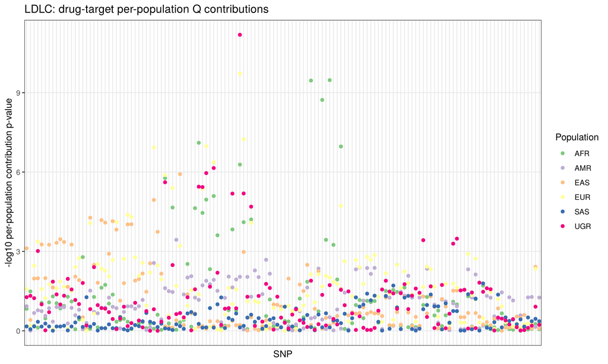

**Drug-target QQ plot and genomic inflation estimates**

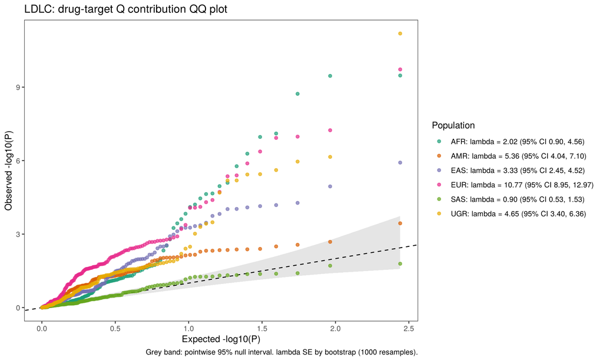

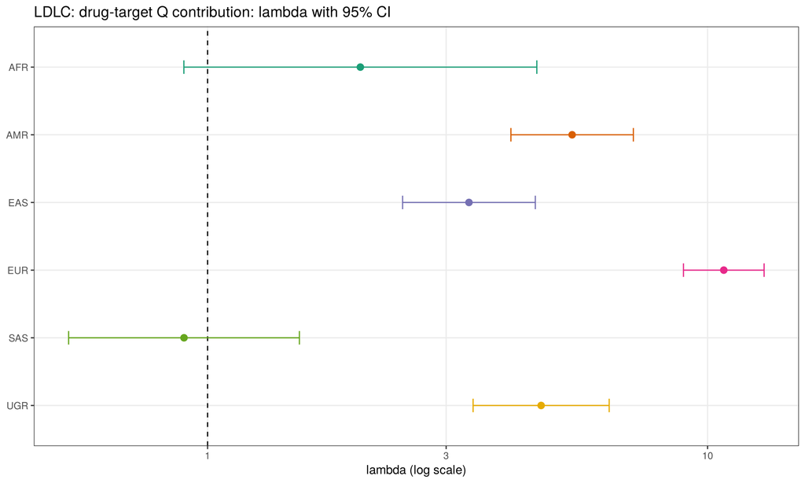

Genomic inflation (lambda) by population with standard error, 95% CI and Wald test of lambda = 1 (CI and test on the log scale; estimates from fewer than ~50 SNPs are imprecise)

| Population | n_snps | lambda | lambda_se | lambda_lci | lambda_uci | p_lambda_eq_1 |
| --- | --- | --- | --- | --- | --- | --- |
| AFR | 138 | 2.021 | 0.838 | 0.897 | 4.555 | 0.090 |
| AMR | 138 | 5.359 | 0.771 | 4.042 | 7.105 | 0.000 |
| EAS | 138 | 3.332 | 0.520 | 2.455 | 4.523 | 0.000 |
| EUR | 138 | 10.775 | 1.021 | 8.949 | 12.973 | 0.000 |
| SAS | 138 | 0.897 | 0.243 | 0.527 | 1.526 | 0.689 |
| UGR | 138 | 4.646 | 0.743 | 3.396 | 6.356 | 0.000 |

**Population-specific estimates for drug-target Bonferroni hits**

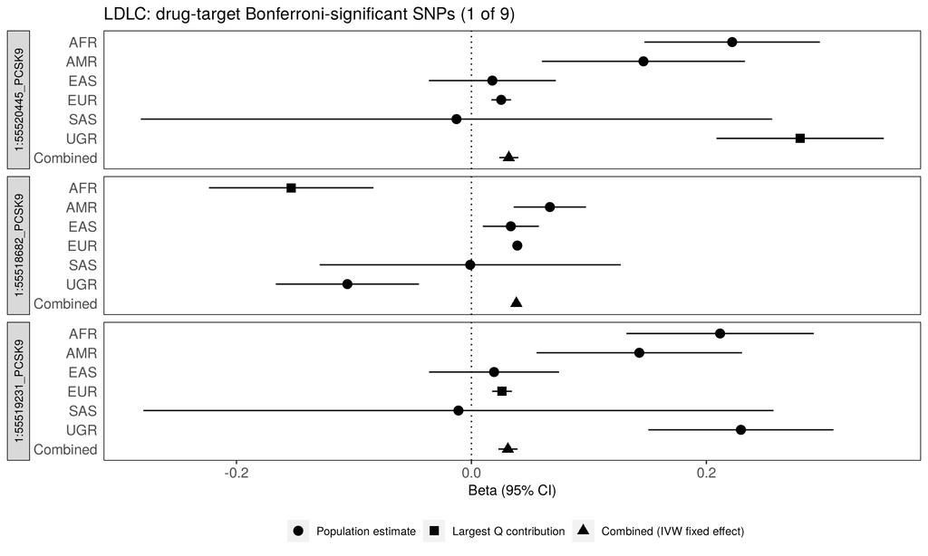

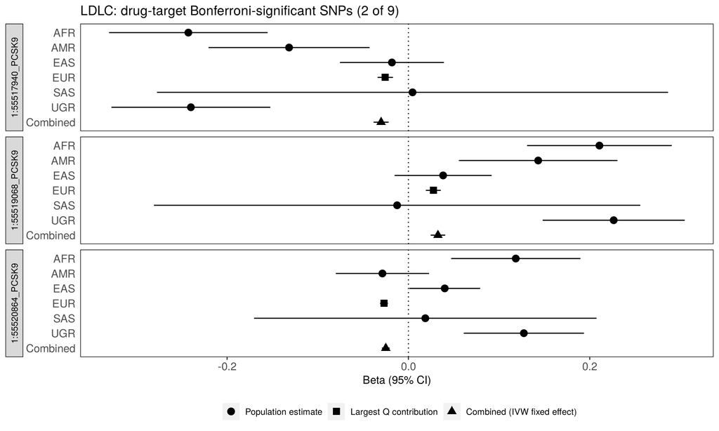

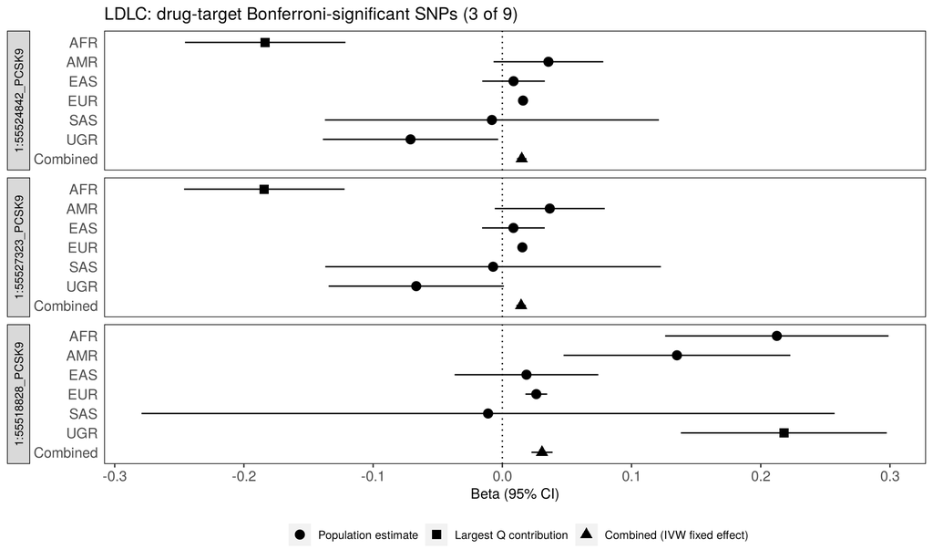

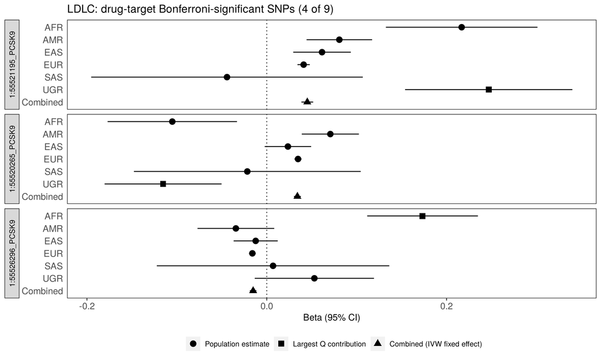

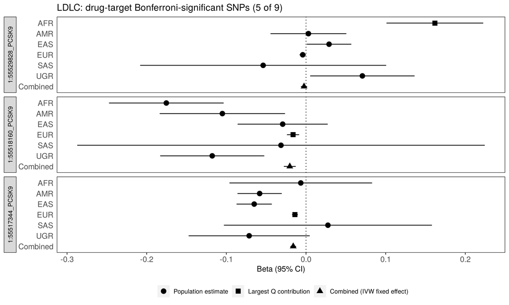

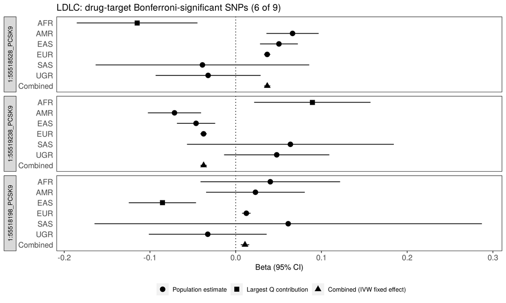

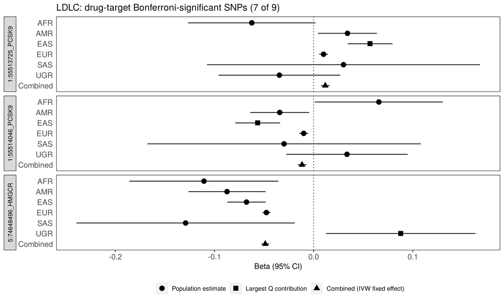

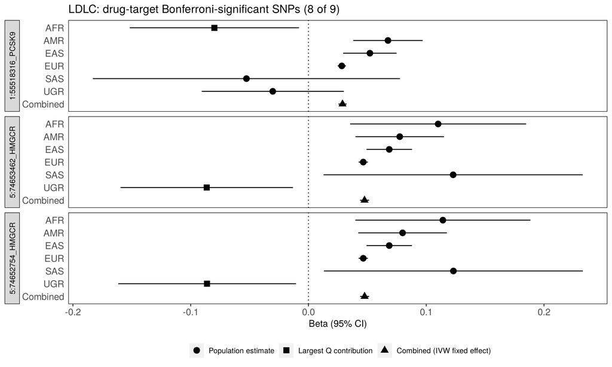

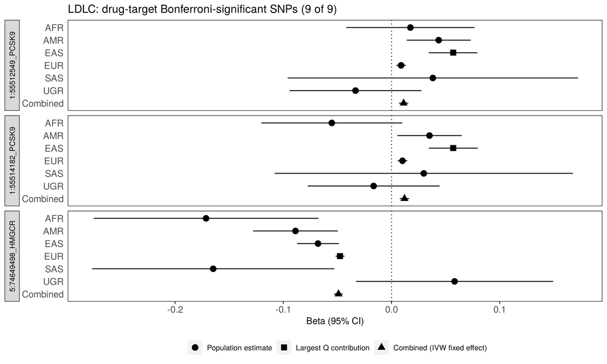

**Per-population Q contribution fractions by drug class**

| Drug | population | variants_with_estimate | fraction_contribution_p_lt_0_05 |
| --- | --- | --- | --- |
| Ezetimibe | AMR | 13 | 0.077 |
| Ezetimibe | EAS | 13 | 0.077 |
| Ezetimibe | EUR | 13 | 0.077 |
| Ezetimibe | SAS | 13 | 0.077 |
| Ezetimibe | AFR | 13 | 0.000 |
| Ezetimibe | UGR | 13 | 0.000 |
| Statins | EUR | 125 | 0.632 |
| Statins | UGR | 125 | 0.408 |
| Statins | EAS | 125 | 0.360 |
| Statins | AMR | 125 | 0.336 |
| Statins | AFR | 125 | 0.272 |
| Statins | SAS | 125 | 0.064 |

### 3.3.3 Expected versus observed replication: drug-target SNPs

Drug-target EUR discovery SNPs with p < 0.05; replication significance alpha = 0.05

| comparison | n_discovery | n_paired | nsnp | metric | datum | value | pdiff |
| --- | --- | --- | --- | --- | --- | --- | --- |
| EUR vs AFR | 113 | 113 | 113 | Sign | Expected | 82.93039 | NA |
| EUR vs AFR | 113 | 113 | 113 | Sign | Observed | 72.00000 | 0.02492 |
| EUR vs AFR | 113 | 113 | 113 | P-value | Expected | 14.81739 | NA |
| EUR vs AFR | 113 | 113 | 113 | P-value | Observed | 43.00000 | 0.00000 |
| EUR vs AMR | 113 | 113 | 113 | Sign | Expected | 98.11724 | NA |
| EUR vs AMR | 113 | 113 | 113 | Sign | Observed | 110.00000 | 0.00023 |
| EUR vs AMR | 113 | 113 | 113 | P-value | Expected | 45.06512 | NA |
| EUR vs AMR | 113 | 113 | 113 | P-value | Observed | 82.00000 | 0.00000 |
| EUR vs EAS | 113 | 113 | 113 | Sign | Expected | 102.70374 | NA |
| EUR vs EAS | 113 | 113 | 113 | Sign | Observed | 107.00000 | 0.19086 |
| EUR vs EAS | 113 | 113 | 113 | P-value | Expected | 57.19537 | NA |
| EUR vs EAS | 113 | 113 | 113 | P-value | Observed | 81.00000 | 0.00001 |
| EUR vs SAS | 113 | 113 | 113 | Sign | Expected | 73.91505 | NA |
| EUR vs SAS | 113 | 113 | 113 | Sign | Observed | 59.00000 | 0.00400 |
| EUR vs SAS | 113 | 113 | 113 | P-value | Expected | 9.17902 | NA |
| EUR vs SAS | 113 | 113 | 113 | P-value | Observed | 21.00000 | 0.00036 |
| EUR vs UGR | 113 | 113 | 113 | Sign | Expected | 84.05258 | NA |
| EUR vs UGR | 113 | 113 | 113 | Sign | Observed | 68.00000 | 0.00110 |
| EUR vs UGR | 113 | 113 | 113 | P-value | Expected | 15.83574 | NA |
| EUR vs UGR | 113 | 113 | 113 | P-value | Observed | 48.00000 | 0.00000 |